# NN_DL_Project_By_Indumathi_April_10_2022

## Author : Indumathi Pandiyan

**Neural Networks and Deep Learning Project** submitted for PGP-AIML Great Learning on 10-Apr-2022

**DOMAIN**: Electronics and Telecommunication  
**CONTEXT**: A communications equipment manufacturing company has a product which is responsible for emitting informative signals. Company wants to build a machine learning model which can help the company to predict the equipment’s signal quality using various parameters.

• **DATA DESCRIPTION**: The data set contains information on various signal tests performed:

**1. Parameters:** Various measurable signalparameters.  
**2. Signal_Quality:** Final signal strength or quality

**• PROJECT OBJECTIVE:** To build a classifier which can use the given parameters to determine the signal strength or quality.

## Steps and tasks: [ Total Score: 30 Marks]

1. Data import and Understanding [10 Marks]

A. Read the ‘Signals.csv’ as DataFrame and import required libraries. [2 Marks]

```python
import matplotlib.pyplot as plt
import pandas as pd
import seaborn as sns
import tensorflow
import matplotlib.pyplot as plt
import seaborn as sns
from sklearn.model_selection import train_test_split
from sklearn.preprocessing import StandardScaler
from keras.models import Sequential
from keras.layers import Dense, Activation, LeakyReLU
from keras import optimizers
# Import label encoder
from sklearn import preprocessing
from tensorflow.keras.utils import to_categorical
```

```python
# Ignore warnings
import warnings
warnings.filterwarnings("ignore")
#
```

### Importing the Signal.csv into dataframe called df

```python
df=pd.read_csv("NN Project Data - Signal.csv")
df.head()
```

|  | Parameter 1 | Parameter 2 | Parameter 3 | Parameter 4 | Parameter 5 | Parameter 6 | Parameter 7 | Parameter 8 | Parameter 9 | Parameter 10 | Parameter 11 | Signal_Strength |
| --- | --- | --- | --- | --- | --- | --- | --- | --- | --- | --- | --- | --- |
| 0 | 7.4 | 0.70 | 0.00 | 1.9 | 0.076 | 11.0 | 34.0 | 0.9978 | 3.51 | 0.56 | 9.4 | 5 |
| 1 | 7.8 | 0.88 | 0.00 | 2.6 | 0.098 | 25.0 | 67.0 | 0.9968 | 3.20 | 0.68 | 9.8 | 5 |
| 2 | 7.8 | 0.76 | 0.04 | 2.3 | 0.092 | 15.0 | 54.0 | 0.9970 | 3.26 | 0.65 | 9.8 | 5 |
| 3 | 11.2 | 0.28 | 0.56 | 1.9 | 0.075 | 17.0 | 60.0 | 0.9980 | 3.16 | 0.58 | 9.8 | 6 |
| 4 | 7.4 | 0.70 | 0.00 | 1.9 | 0.076 | 11.0 | 34.0 | 0.9978 | 3.51 | 0.56 | 9.4 | 5 |

```python
df.shape
```

```
(1599, 12)
```

**Comments:**  
There are 1599 records and 12 features . Out of which 11 are signal fparameters and Signal strength is target feature.

```python
df.describe().T
```

|  | count | mean | std | min | 25% | 50% | 75% | max |
| --- | --- | --- | --- | --- | --- | --- | --- | --- |
| Parameter 1 | 1599.0 | 8.319637 | 1.741096 | 4.60000 | 7.1000 | 7.90000 | 9.200000 | 15.90000 |
| Parameter 2 | 1599.0 | 0.527821 | 0.179060 | 0.12000 | 0.3900 | 0.52000 | 0.640000 | 1.58000 |
| Parameter 3 | 1599.0 | 0.270976 | 0.194801 | 0.00000 | 0.0900 | 0.26000 | 0.420000 | 1.00000 |
| Parameter 4 | 1599.0 | 2.538806 | 1.409928 | 0.90000 | 1.9000 | 2.20000 | 2.600000 | 15.50000 |
| Parameter 5 | 1599.0 | 0.087467 | 0.047065 | 0.01200 | 0.0700 | 0.07900 | 0.090000 | 0.61100 |
| Parameter 6 | 1599.0 | 15.874922 | 10.460157 | 1.00000 | 7.0000 | 14.00000 | 21.000000 | 72.00000 |
| Parameter 7 | 1599.0 | 46.467792 | 32.895324 | 6.00000 | 22.0000 | 38.00000 | 62.000000 | 289.00000 |
| Parameter 8 | 1599.0 | 0.996747 | 0.001887 | 0.99007 | 0.9956 | 0.99675 | 0.997835 | 1.00369 |
| Parameter 9 | 1599.0 | 3.311113 | 0.154386 | 2.74000 | 3.2100 | 3.31000 | 3.400000 | 4.01000 |
| Parameter 10 | 1599.0 | 0.658149 | 0.169507 | 0.33000 | 0.5500 | 0.62000 | 0.730000 | 2.00000 |
| Parameter 11 | 1599.0 | 10.422983 | 1.065668 | 8.40000 | 9.5000 | 10.20000 | 11.100000 | 14.90000 |
| Signal_Strength | 1599.0 | 5.636023 | 0.807569 | 3.00000 | 5.0000 | 6.00000 | 6.000000 | 8.00000 |

B. Check for missing values and print percentage for each attribute. [2 Marks]

```python
## Method to check the missing value
def check_missingvlaue(data):
    percent_missing = round(data.isnull().sum() * 100 / len(data),2) #percentage of missing value
    missing_count=data.isnull().sum()
    missing_value_data = pd.DataFrame({'Feature Name': data.columns,
                                       'missing value count': missing_count,
                                       'percent_missing': percent_missing})
    print(missing_value_data)
```

```python
check_missingvlaue(df)
```

```
                    Feature Name  missing value count  percent_missing
Parameter 1          Parameter 1                    0              0.0
Parameter 2          Parameter 2                    0              0.0
Parameter 3          Parameter 3                    0              0.0
Parameter 4          Parameter 4                    0              0.0
Parameter 5          Parameter 5                    0              0.0
Parameter 6          Parameter 6                    0              0.0
Parameter 7          Parameter 7                    0              0.0
Parameter 8          Parameter 8                    0              0.0
Parameter 9          Parameter 9                    0              0.0
Parameter 10        Parameter 10                    0              0.0
Parameter 11        Parameter 11                    0              0.0
Signal_Strength  Signal_Strength                    0              0.0
```

**Observation**: Verified missing values and those percentagae. There are no missing values found.

C. Check for presence of duplicate records in the dataset and impute with appropriate method. [2 Marks]

```python
df.duplicated().sum()
```

```
240
```

**Observation**:  
There are 240 duplicate records found.

```python
duplicate = df[df.duplicated()]

print("Duplicate Rows :")
```

```
Duplicate Rows :
```

```python
duplicate.head()
```

|  | Parameter 1 | Parameter 2 | Parameter 3 | Parameter 4 | Parameter 5 | Parameter 6 | Parameter 7 | Parameter 8 | Parameter 9 | Parameter 10 | Parameter 11 | Signal_Strength |
| --- | --- | --- | --- | --- | --- | --- | --- | --- | --- | --- | --- | --- |
| 4 | 7.4 | 0.700 | 0.00 | 1.90 | 0.076 | 11.0 | 34.0 | 0.9978 | 3.51 | 0.56 | 9.4 | 5 |
| 11 | 7.5 | 0.500 | 0.36 | 6.10 | 0.071 | 17.0 | 102.0 | 0.9978 | 3.35 | 0.80 | 10.5 | 5 |
| 27 | 7.9 | 0.430 | 0.21 | 1.60 | 0.106 | 10.0 | 37.0 | 0.9966 | 3.17 | 0.91 | 9.5 | 5 |
| 40 | 7.3 | 0.450 | 0.36 | 5.90 | 0.074 | 12.0 | 87.0 | 0.9978 | 3.33 | 0.83 | 10.5 | 5 |
| 65 | 7.2 | 0.725 | 0.05 | 4.65 | 0.086 | 4.0 | 11.0 | 0.9962 | 3.41 | 0.39 | 10.9 | 5 |

```python
duplicate.shape
```

```
(240, 12)
```

```python
df=df.drop_duplicates()
```

```python
df.shape
```

```
(1359, 12)
```

**Observation**: As duplicates has no value for model preparation dropped them. Hence now there are 1359 records.

D. Visualise distribution of the target variable. [2 Marks]

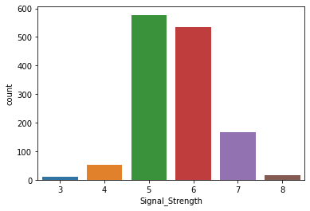

```python
#plotting the graph
sns.countplot(x='Signal_Strength',data=df)
plt.show()
```

**Observation**: Out of the 6 different signal strengths available the counts of 5 and 6 are comparatively high than other four.

```python
# get count
signal_count = pd.DataFrame(df.groupby('Signal_Strength').size(), columns=['count'])
signal_count
```

| Signal_Strength | count |
| --- | --- |
| 3 | 10 |
| 4 | 53 |
| 5 | 577 |
| 6 | 535 |
| 7 | 167 |
| 8 | 17 |

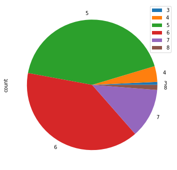

```python
plt.rcParams['figure.figsize'] = (10, 6)
signal_count.plot(kind='pie', subplots=True)
plt.show()
```

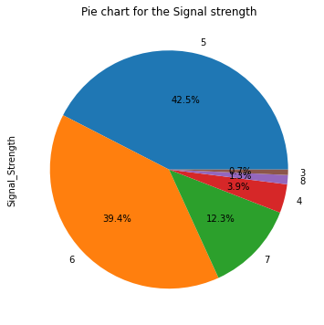

```python
plt.rcParams['figure.figsize'] = (10, 6)
#define data
labels = ['Signal_Strength']

#define Seaborn color palette to use
colors = sns.color_palette('pastel')[0:5]
plt.title("Pie chart for the Signal strength")
df['Signal_Strength'].value_counts().plot.pie(autopct='%1.1f%%',shadow=False)
plt.show()
```

**Observation**: Out of the 6 different signal strengths available the counts of 5 and 6 are comparatively high than other four. **42.5%** of data having signal strength 5 whereas singal strength is 6 for **39.4%** of the data

E. Share insights from the initial data analysis (at least 2). [2 Marks]

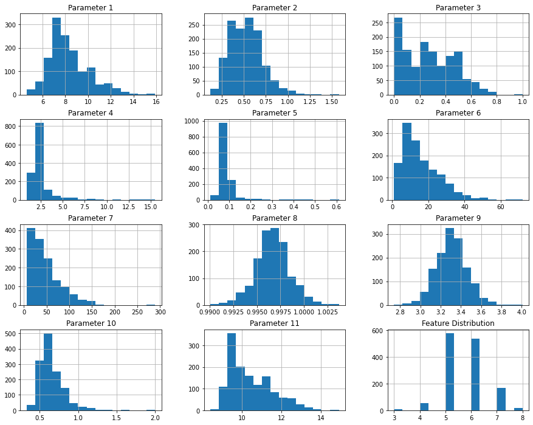

```python
df.hist(figsize=(15,12),bins = 15)
plt.title("Feature Distribution")
plt.show()
```

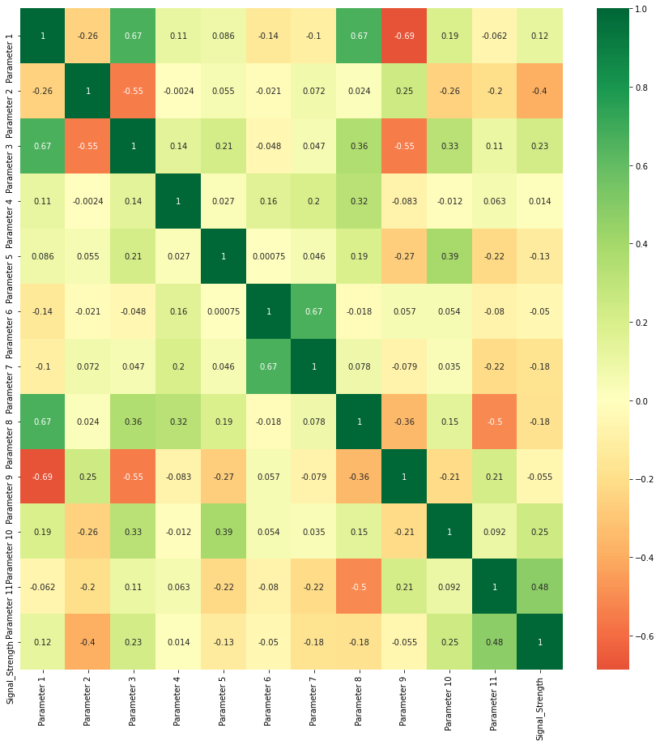

```python
plt.figure(figsize=(15,15))
p=sns.heatmap(df.corr(), annot=True,cmap='RdYlGn',center=0)
```

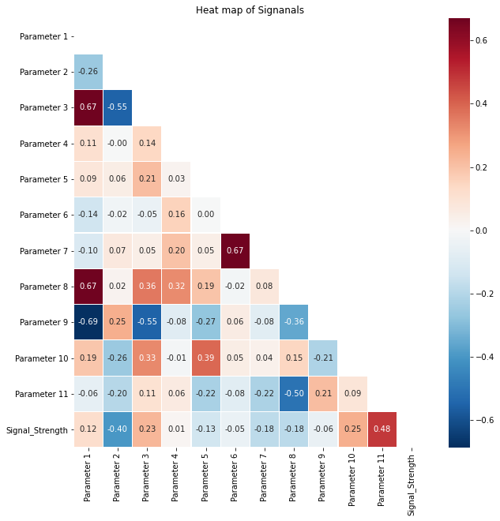

```python
  fig, ax = plt.subplots(figsize=(10,10))
#sns.heatmap(df2.corr(), center=0, cmap='BrBG', annot=True)
# Generate a mask for the upper triangle
mask = np.triu(np.ones_like(df.corr(), dtype=bool))
sns.heatmap(df.corr(), center=0, cmap='RdBu_r', annot=True, fmt='.2f', linewidths=0.05, mask=mask)
ax.set_title('Heat map of Signanals')
```

**Observations**

- From the Heatmap parameter 1 is highly correlated with Parameter 3, 8 and 9
- Parameter 6 is highly correlated with Parameter 7 *

**Note:** Correlation threshold is 0.6

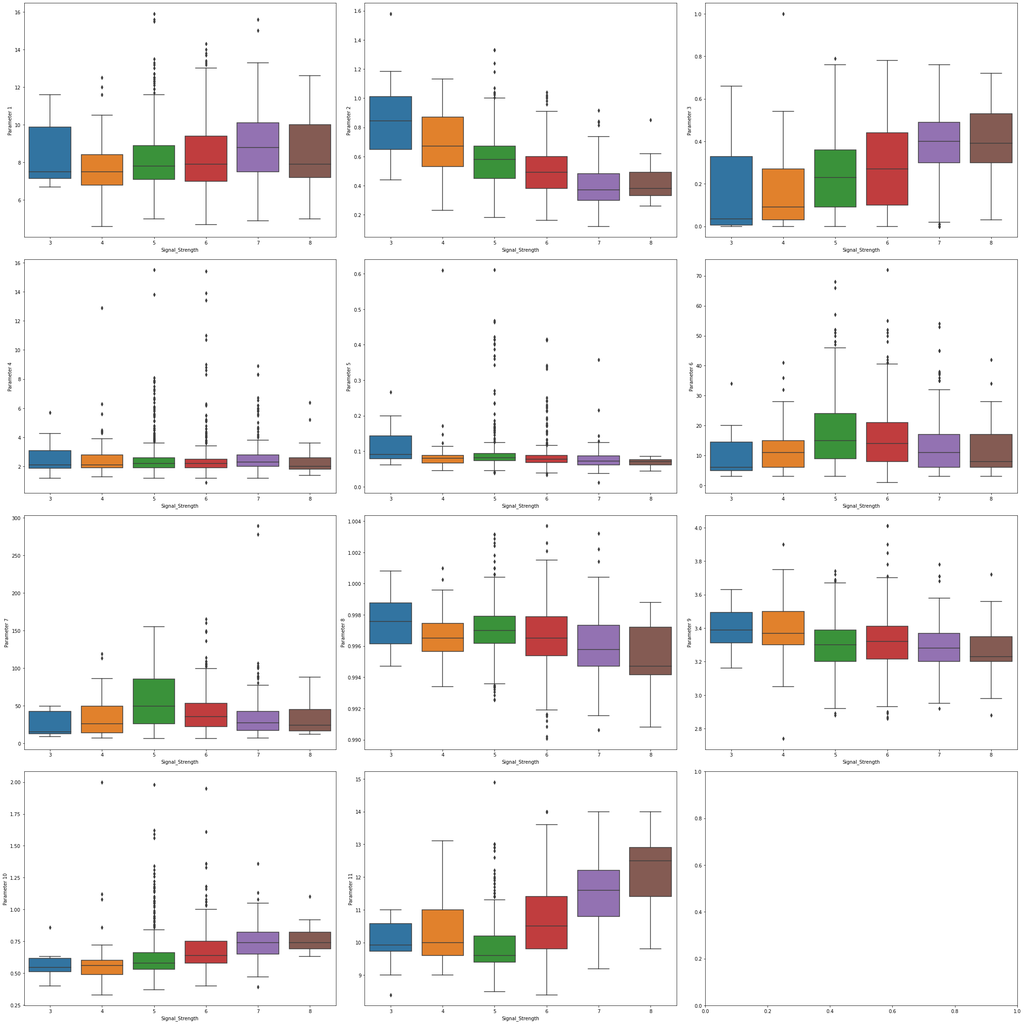

```python
fig,ax = plt.subplots(nrows = 4, ncols=3, figsize=(30,30))
row = 0
col = 0
for i in range(len(df.columns) -1):
    if col > 2:
        row += 1
        col = 0
    axes = ax[row,col]
    sns.boxplot(x = df['Signal_Strength'], y = df[df.columns[i]],ax = axes)
    col += 1
plt.tight_layout()
# plt.title("Individual Features by Class")
plt.show()
```

**Insights on Initial Data Analysis**

```
*  The signal strengths are available as 6 classes/ types. 3,4,5,6,7 and 8 respectively.
*  There are 11 independant features in the dataset through which we need to classify the Signal strength
*  As signal strengths are more than 2, we need to do a classifier for Multiclass classification
*  Signal Strength 5 and 6 are occupying the most percentage of dataset so certainly its imbalanced dataset.
*  For improving the prediction we may need to upsample
*  From the box plot its evident that lot of outliers present in the dataset especially for 5 and 6 signal strength
```

## 2. Data Preprocessing

A. Split the data into X & Y. [1 Marks]

```python
# Split data into X and Y
# Create a separate dataframe consisting only of the features i.e independent attributes
X = df.drop(labels= "Signal_Strength" , axis = 1)
y = df["Signal_Strength"]
X.head()
```

|  | Parameter 1 | Parameter 2 | Parameter 3 | Parameter 4 | Parameter 5 | Parameter 6 | Parameter 7 | Parameter 8 | Parameter 9 | Parameter 10 | Parameter 11 |
| --- | --- | --- | --- | --- | --- | --- | --- | --- | --- | --- | --- |
| 0 | 7.4 | 0.70 | 0.00 | 1.9 | 0.076 | 11.0 | 34.0 | 0.9978 | 3.51 | 0.56 | 9.4 |
| 1 | 7.8 | 0.88 | 0.00 | 2.6 | 0.098 | 25.0 | 67.0 | 0.9968 | 3.20 | 0.68 | 9.8 |
| 2 | 7.8 | 0.76 | 0.04 | 2.3 | 0.092 | 15.0 | 54.0 | 0.9970 | 3.26 | 0.65 | 9.8 |
| 3 | 11.2 | 0.28 | 0.56 | 1.9 | 0.075 | 17.0 | 60.0 | 0.9980 | 3.16 | 0.58 | 9.8 |
| 5 | 7.4 | 0.66 | 0.00 | 1.8 | 0.075 | 13.0 | 40.0 | 0.9978 | 3.51 | 0.56 | 9.4 |

```python
y.head()
```

```
0    5
1    5
2    5
3    6
5    5
Name: Signal_Strength, dtype: int64
```

B. Split the data into train & test with 70:30 proportion.[1 Marks]

```python
# Split X and y into training and test set in 70:30 ratio
X_train, X_test, y_train, y_test = train_test_split(X, y, test_size=0.30, random_state=42)
```

C.Print shape of all the 4 variables and verify if train and test data is in sync. [1 Marks]

```python
print('Train data shape')
print('---------------')
print(X_train.shape)
print(y_train.shape)
print('Test data shape')
print('---------------')
print(X_test.shape)
print(y_test.shape)
```

```
Train data shape
---------------
(951, 11)
(951,)
Test data shape
---------------
(408, 11)
(408,)
```

**Observation**  
It is observed that Train data and Test data both are in sync

```python
print('y_test unique classes', np.unique(y_test))
```

```
y_test unique classes [3 4 5 6 7 8]
```

```python
print('y_train unique classes', np.unique(y_train))
```

```
y_train unique classes [3 4 5 6 7 8]
```

D. Normalise the train and test data with appropriate method. [2 Marks]

```python
# Normalize train data
X_train_std = StandardScaler().fit_transform(X_train)

# Normalize test data
X_test_std = StandardScaler().fit_transform(X_test)
```

E.Transform Labels into format acceptable by Neural Network [2 Marks]

```python
y.shape
```

```
(1359,)
```

```python
y_train=to_categorical(y_train)
y_test=to_categorical(y_test)
```

```python
y.nunique()
```

```
6
```

```python
print('X_train Shape', X_train_std.shape)
#print('X_val Shape', X_val.shape)
print('X_test Shape',X_test_std.shape)
```

```
X_train Shape (951, 11)
X_test Shape (408, 11)
```

```python
print('y_train Shape', y_train.shape)
#print('y_val Shape', y_val.shape)
print('y_test Shape',y_test.shape)
```

```
y_train Shape (951, 9)
y_test Shape (408, 9)
```

```python
print(y_train.shape[1])
```

```
9
```

## 3.Model Training & Evaluation using Neural Network [13 Marks]

#### Neural network:

Neural Network has following objects

- Layers, which are combined into a network (or model)
- The input data and corresponding targets
- The loss function, which defines the feedback signal used for learning
- The optimizer, which determines how learning proceeds

A neural network has 6 important concepts

- Weights
- Layers
- Forward propagation
- Back propagation — Use the results of forward propogation/weights to get S
- Calculating the cost/gradient of each weight
- Gradient descent — find the best weight/hypothesis

A. Design a Neural Network to train a classifier. [3 Marks]

```python
input_layer_size = 11                      # Dimension of features
hidden_layer_size = 8 # Average of Input and output layers
hidden_layer_size1 = input_layer_size*2    # of units in hidden layer
hidden_layer_size2 = input_layer_size*3
output_layer_size = y_train.shape[1]   # number of labels
```

```python
print(input_layer_size)
print(hidden_layer_size1)
print(hidden_layer_size2)
print(output_layer_size)
```

```
11
22
33
9
```

### Base Neural network Model for classification

```python
## Creating the model
##initializing the Model
model_class = Sequential()

## input the first layer with input dimensions. Here the input parameters are 11

# The amount of nodes (dimensions) in hidden layer should be the average of input and output layers, in this case 6.
# This adds the input layer (by specifying input dimension) AND the first hidden layer (units)
#model_class.add(Dense(input_layer_size, activation='relu'))
model_class.add(Dense(activation = 'relu', input_dim = input_layer_size, units=hidden_layer_size1, kernel_initializer='uniform'))

## Adding first hidden Layer
model_class.add(Dense(input_layer_size, activation='relu',kernel_initializer='uniform'))

# Adding the output layer
# Notice that we do not need to specify input dim.
# we have an output of 6 node, which is the the desired dimensions of our output
# We use the softmax because we have multiclass classification problem
## setting softmax for output layer
model_class.add(Dense(output_layer_size, activation='softmax'))
```

B.Train the classifier using previously designed Architecture [2 Marks]

```python
# Create optimizer with default learning rate
# Compile the model
## Categorical cross_entrophy is used as multiclass classificaton problem
model_class.compile(loss="categorical_crossentropy", metrics=["accuracy"], optimizer="sgd")

# Fit the model
model_class.fit(x=X_train_std, y=y_train, batch_size=20, epochs=100, validation_data=(X_test_std, y_test))
```

```
<keras.callbacks.History at 0x150801574f0>
```

```python
## visualize model
model_class.summary()
```

[output not shown]

```python
# Final evaluation of the model
scores = model_class.evaluate(X_test_std, y_test, verbose=0)
print("Loss:", scores[0])
print("Accuracy:", scores[1])
```

```
Loss: 0.9341722130775452
Accuracy: 0.6102941036224365
```

```python
## Choose a loss function and optimizer

from tensorflow.keras.optimizers import SGD

#Creating an Stochastic Gradient Descent
sgd = SGD(lr = 0.01, momentum = 0.9)

# Compiling our model
model_class.compile(optimizer = sgd,
                   loss = 'categorical_crossentropy',
                   metrics = ['accuracy'])
#optimizers list
#optimizers['SGD', 'RMSprop', 'Adagrad', 'Adadelta', 'Adam', 'Adamax', 'Nadam']

# Fitting the ANN to the Training set
model_class.fit(X_train_std, y_train,
                                     batch_size = 60,
                                     epochs = 30, verbose=2)
```

```
16/16 - 1s - loss: 0.9770 - accuracy: 0.5973 - 864ms/epoch - 54ms/step
16/16 - 0s - loss: 0.9746 - accuracy: 0.5983 - 25ms/epoch - 2ms/step
16/16 - 0s - loss: 0.9726 - accuracy: 0.5962 - 27ms/epoch - 2ms/step
16/16 - 0s - loss: 0.9678 - accuracy: 0.5994 - 28ms/epoch - 2ms/step
16/16 - 0s - loss: 0.9638 - accuracy: 0.6046 - 25ms/epoch - 2ms/step
16/16 - 0s - loss: 0.9608 - accuracy: 0.6025 - 27ms/epoch - 2ms/step
16/16 - 0s - loss: 0.9605 - accuracy: 0.5994 - 27ms/epoch - 2ms/step
16/16 - 0s - loss: 0.9588 - accuracy: 0.5941 - 28ms/epoch - 2ms/step
16/16 - 0s - loss: 0.9587 - accuracy: 0.5952 - 28ms/epoch - 2ms/step
16/16 - 0s - loss: 0.9504 - accuracy: 0.6078 - 34ms/epoch - 2ms/step
16/16 - 0s - loss: 0.9481 - accuracy: 0.5994 - 27ms/epoch - 2ms/step
16/16 - 0s - loss: 0.9448 - accuracy: 0.6015 - 29ms/epoch - 2ms/step
16/16 - 0s - loss: 0.9431 - accuracy: 0.6015 - 29ms/epoch - 2ms/step
16/16 - 0s - loss: 0.9395 - accuracy: 0.6025 - 28ms/epoch - 2ms/step
16/16 - 0s - loss: 0.9366 - accuracy: 0.6130 - 26ms/epoch - 2ms/step
16/16 - 0s - loss: 0.9348 - accuracy: 0.6004 - 28ms/epoch - 2ms/step
16/16 - 0s - loss: 0.9325 - accuracy: 0.6109 - 28ms/epoch - 2ms/step
16/16 - 0s - loss: 0.9343 - accuracy: 0.6078 - 28ms/epoch - 2ms/step
16/16 - 0s - loss: 0.9299 - accuracy: 0.6067 - 27ms/epoch - 2ms/step
16/16 - 0s - loss: 0.9257 - accuracy: 0.6193 - 27ms/epoch - 2ms/step
16/16 - 0s - loss: 0.9230 - accuracy: 0.6204 - 21ms/epoch - 1ms/step
16/16 - 0s - loss: 0.9201 - accuracy: 0.6204 - 26ms/epoch - 2ms/step
16/16 - 0s - loss: 0.9209 - accuracy: 0.6151 - 25ms/epoch - 2ms/step
16/16 - 0s - loss: 0.9168 - accuracy: 0.6236 - 25ms/epoch - 2ms/step
16/16 - 0s - loss: 0.9166 - accuracy: 0.6141 - 28ms/epoch - 2ms/step
16/16 - 0s - loss: 0.9163 - accuracy: 0.6088 - 25ms/epoch - 2ms/step
16/16 - 0s - loss: 0.9169 - accuracy: 0.6130 - 27ms/epoch - 2ms/step
16/16 - 0s - loss: 0.9139 - accuracy: 0.6120 - 25ms/epoch - 2ms/step
16/16 - 0s - loss: 0.9111 - accuracy: 0.6151 - 23ms/epoch - 1ms/step
16/16 - 0s - loss: 0.9104 - accuracy: 0.6225 - 21ms/epoch - 1ms/step
```

```
<keras.callbacks.History at 0x1508d641d90>
```

```python
# Final evaluation of the model
scores = model_class.evaluate(X_test_std, y_test, verbose=0)
print("Loss:", scores[0])
print("Accuracy:", scores[1])
```

[output not shown]

```python
#Model Evaluation
print("Training set score: ",model_class.evaluate(X_train_std, y_train,verbose=0))
print("Test set score: " ,model_class.evaluate(X_test_std, y_test,verbose=0))
```

```
Training set score:  [0.9016122221946716, 0.6256572008132935]
Test set score:  [0.9097743034362793, 0.6225489974021912]
```

```python
# Pickle file for future use
model_class.save("classifier_model.h5")
print("model file saved successfully!")
```

```
model file saved successfully!
```

```python
### Fitting the model

training_history = model_class.fit(X_train_std, y_train, validation_data=(X_test_std, y_test), epochs=100, batch_size=300, verbose=2)
```

```
4/4 - 0s - loss: 0.9018 - accuracy: 0.6236 - val_loss: 0.9108 - val_accuracy: 0.6275 - 107ms/epoch - 27ms/step
4/4 - 0s - loss: 0.9016 - accuracy: 0.6193 - val_loss: 0.9114 - val_accuracy: 0.6250 - 77ms/epoch - 19ms/step
4/4 - 0s - loss: 0.9008 - accuracy: 0.6225 - val_loss: 0.9121 - val_accuracy: 0.6176 - 61ms/epoch - 15ms/step
4/4 - 0s - loss: 0.9006 - accuracy: 0.6236 - val_loss: 0.9127 - val_accuracy: 0.6176 - 62ms/epoch - 15ms/step
4/4 - 0s - loss: 0.9002 - accuracy: 0.6257 - val_loss: 0.9135 - val_accuracy: 0.6201 - 61ms/epoch - 15ms/step
4/4 - 0s - loss: 0.9006 - accuracy: 0.6215 - val_loss: 0.9138 - val_accuracy: 0.6201 - 62ms/epoch - 15ms/step
4/4 - 0s - loss: 0.9000 - accuracy: 0.6246 - val_loss: 0.9132 - val_accuracy: 0.6201 - 60ms/epoch - 15ms/step
4/4 - 0s - loss: 0.8993 - accuracy: 0.6225 - val_loss: 0.9126 - val_accuracy: 0.6225 - 62ms/epoch - 15ms/step
4/4 - 0s - loss: 0.8987 - accuracy: 0.6257 - val_loss: 0.9123 - val_accuracy: 0.6225 - 65ms/epoch - 16ms/step
4/4 - 0s - loss: 0.8990 - accuracy: 0.6309 - val_loss: 0.9137 - val_accuracy: 0.6176 - 61ms/epoch - 15ms/step
4/4 - 0s - loss: 0.8989 - accuracy: 0.6309 - val_loss: 0.9137 - val_accuracy: 0.6250 - 62ms/epoch - 16ms/step
4/4 - 0s - loss: 0.8979 - accuracy: 0.6278 - val_loss: 0.9136 - val_accuracy: 0.6225 - 62ms/epoch - 15ms/step
4/4 - 0s - loss: 0.8980 - accuracy: 0.6341 - val_loss: 0.9140 - val_accuracy: 0.6201 - 65ms/epoch - 16ms/step
4/4 - 0s - loss: 0.8973 - accuracy: 0.6299 - val_loss: 0.9141 - val_accuracy: 0.6201 - 63ms/epoch - 16ms/step
4/4 - 0s - loss: 0.8967 - accuracy: 0.6288 - val_loss: 0.9135 - val_accuracy: 0.6225 - 65ms/epoch - 16ms/step
4/4 - 0s - loss: 0.8962 - accuracy: 0.6257 - val_loss: 0.9150 - val_accuracy: 0.6152 - 50ms/epoch - 12ms/step
4/4 - 0s - loss: 0.8963 - accuracy: 0.6204 - val_loss: 0.9168 - val_accuracy: 0.6176 - 57ms/epoch - 14ms/step
4/4 - 0s - loss: 0.8977 - accuracy: 0.6151 - val_loss: 0.9182 - val_accuracy: 0.6176 - 53ms/epoch - 13ms/step
4/4 - 0s - loss: 0.8956 - accuracy: 0.6162 - val_loss: 0.9168 - val_accuracy: 0.6176 - 44ms/epoch - 11ms/step
4/4 - 0s - loss: 0.8938 - accuracy: 0.6288 - val_loss: 0.9177 - val_accuracy: 0.6176 - 60ms/epoch - 15ms/step
4/4 - 0s - loss: 0.8958 - accuracy: 0.6236 - val_loss: 0.9192 - val_accuracy: 0.6078 - 40ms/epoch - 10ms/step
4/4 - 0s - loss: 0.8947 - accuracy: 0.6236 - val_loss: 0.9179 - val_accuracy: 0.6152 - 55ms/epoch - 14ms/step
4/4 - 0s - loss: 0.8934 - accuracy: 0.6299 - val_loss: 0.9183 - val_accuracy: 0.6152 - 35ms/epoch - 9ms/step
4/4 - 0s - loss: 0.8931 - accuracy: 0.6257 - val_loss: 0.9185 - val_accuracy: 0.6176 - 40ms/epoch - 10ms/step
4/4 - 0s - loss: 0.8933 - accuracy: 0.6225 - val_loss: 0.9178 - val_accuracy: 0.6152 - 39ms/epoch - 10ms/step
4/4 - 0s - loss: 0.8919 - accuracy: 0.6215 - val_loss: 0.9180 - val_accuracy: 0.6103 - 63ms/epoch - 16ms/step
4/4 - 0s - loss: 0.8922 - accuracy: 0.6257 - val_loss: 0.9174 - val_accuracy: 0.6152 - 52ms/epoch - 13ms/step
4/4 - 0s - loss: 0.8925 - accuracy: 0.6236 - val_loss: 0.9169 - val_accuracy: 0.6152 - 32ms/epoch - 8ms/step
4/4 - 0s - loss: 0.8918 - accuracy: 0.6193 - val_loss: 0.9186 - val_accuracy: 0.6127 - 41ms/epoch - 10ms/step
4/4 - 0s - loss: 0.8920 - accuracy: 0.6204 - val_loss: 0.9189 - val_accuracy: 0.6054 - 28ms/epoch - 7ms/step
4/4 - 0s - loss: 0.8923 - accuracy: 0.6225 - val_loss: 0.9210 - val_accuracy: 0.6152 - 41ms/epoch - 10ms/step
4/4 - 0s - loss: 0.8912 - accuracy: 0.6267 - val_loss: 0.9203 - val_accuracy: 0.6225 - 32ms/epoch - 8ms/step
4/4 - 0s - loss: 0.8902 - accuracy: 0.6288 - val_loss: 0.9198 - val_accuracy: 0.6225 - 32ms/epoch - 8ms/step
4/4 - 0s - loss: 0.8896 - accuracy: 0.6341 - val_loss: 0.9195 - val_accuracy: 0.6201 - 29ms/epoch - 7ms/step
4/4 - 0s - loss: 0.8894 - accuracy: 0.6288 - val_loss: 0.9193 - val_accuracy: 0.6250 - 29ms/epoch - 7ms/step
4/4 - 0s - loss: 0.8908 - accuracy: 0.6204 - val_loss: 0.9197 - val_accuracy: 0.6225 - 36ms/epoch - 9ms/step
4/4 - 0s - loss: 0.8896 - accuracy: 0.6257 - val_loss: 0.9191 - val_accuracy: 0.6176 - 27ms/epoch - 7ms/step
4/4 - 0s - loss: 0.8875 - accuracy: 0.6351 - val_loss: 0.9203 - val_accuracy: 0.6127 - 38ms/epoch - 9ms/step
4/4 - 0s - loss: 0.8880 - accuracy: 0.6341 - val_loss: 0.9200 - val_accuracy: 0.6152 - 37ms/epoch - 9ms/step
4/4 - 0s - loss: 0.8875 - accuracy: 0.6341 - val_loss: 0.9179 - val_accuracy: 0.6201 - 32ms/epoch - 8ms/step
```

[output cut: 45 more lines]

```
4/4 - 0s - loss: 0.8700 - accuracy: 0.6330 - val_loss: 0.9330 - val_accuracy: 0.6103 - 32ms/epoch - 8ms/step
4/4 - 0s - loss: 0.8706 - accuracy: 0.6341 - val_loss: 0.9357 - val_accuracy: 0.5980 - 36ms/epoch - 9ms/step
4/4 - 0s - loss: 0.8715 - accuracy: 0.6309 - val_loss: 0.9363 - val_accuracy: 0.5931 - 30ms/epoch - 7ms/step
4/4 - 0s - loss: 0.8701 - accuracy: 0.6299 - val_loss: 0.9349 - val_accuracy: 0.6005 - 35ms/epoch - 9ms/step
4/4 - 0s - loss: 0.8686 - accuracy: 0.6341 - val_loss: 0.9340 - val_accuracy: 0.6054 - 39ms/epoch - 10ms/step
4/4 - 0s - loss: 0.8689 - accuracy: 0.6320 - val_loss: 0.9342 - val_accuracy: 0.6005 - 37ms/epoch - 9ms/step
4/4 - 0s - loss: 0.8680 - accuracy: 0.6351 - val_loss: 0.9339 - val_accuracy: 0.6078 - 51ms/epoch - 13ms/step
4/4 - 0s - loss: 0.8684 - accuracy: 0.6299 - val_loss: 0.9341 - val_accuracy: 0.6054 - 42ms/epoch - 10ms/step
4/4 - 0s - loss: 0.8677 - accuracy: 0.6341 - val_loss: 0.9342 - val_accuracy: 0.5980 - 46ms/epoch - 12ms/step
4/4 - 0s - loss: 0.8670 - accuracy: 0.6362 - val_loss: 0.9328 - val_accuracy: 0.6029 - 42ms/epoch - 10ms/step
4/4 - 0s - loss: 0.8663 - accuracy: 0.6341 - val_loss: 0.9311 - val_accuracy: 0.5980 - 36ms/epoch - 9ms/step
4/4 - 0s - loss: 0.8659 - accuracy: 0.6341 - val_loss: 0.9311 - val_accuracy: 0.6054 - 35ms/epoch - 9ms/step
4/4 - 0s - loss: 0.8661 - accuracy: 0.6320 - val_loss: 0.9327 - val_accuracy: 0.6029 - 34ms/epoch - 8ms/step
4/4 - 0s - loss: 0.8659 - accuracy: 0.6299 - val_loss: 0.9328 - val_accuracy: 0.6103 - 34ms/epoch - 8ms/step
4/4 - 0s - loss: 0.8650 - accuracy: 0.6309 - val_loss: 0.9310 - val_accuracy: 0.5956 - 39ms/epoch - 10ms/step
```

C. Plot 2 separate visuals. [3 Marks]

i. Training Loss and Validation Loss

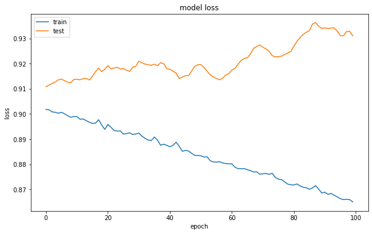

```python
# summarizing historical accuracy
# summarize history for loss
plt.plot(training_history.history['loss'])
plt.plot(training_history.history['val_loss'])
plt.title('model loss')
plt.ylabel('loss')
plt.xlabel('epoch')
plt.legend(['train', 'test'], loc='upper left')
plt.show()
```

ii. Training Accuracy and Validation Accuracy

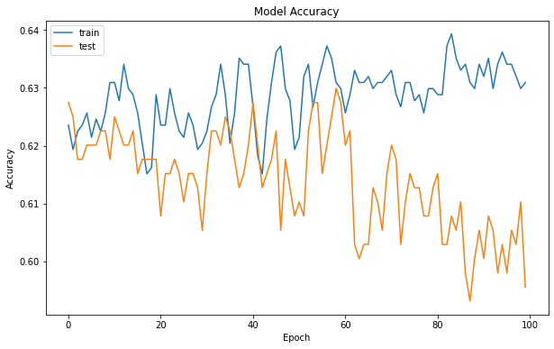

```python
# summarizing historical accuracy
plt.plot(training_history.history['accuracy'])
plt.plot(training_history.history['val_accuracy'])
plt.title('Model Accuracy')
plt.ylabel('Accuracy')
plt.xlabel('Epoch')
plt.legend(['train', 'test'], loc='upper left')
plt.show()
```

D. Design new architecture/update existing architecture in attempt to improve the performance of the model. [2 Marks]

Optimize the model Some important parameters to look out for while optimizing neural networks are:

-Type of architecture

-Number of Layers

-Number of Neurons in a layer

-Regularization parameters

-Learning Rate

-Type of optimization / backpropagation technique to use

-Dropout rate

-Weight sharing

### Rebuilding the model

```python
## Creating the model
##initializing the Model
new_model = Sequential()

## input the first layer with input dimensions. Here the input parameters are 11

# The amount of nodes (dimensions) in hidden layer should be the average of input and output layers, in this case 6.
# This adds the input layer (by specifying input dimension) AND the first hidden layer (units)
#model_class.add(Dense(input_layer_size, activation='relu'))
new_model.add(Dense(activation = 'relu', input_dim = input_layer_size, units=hidden_layer_size1, kernel_initializer='uniform'))

## Adding first hidden Layer
new_model.add(Dense(hidden_layer_size1, activation='relu',kernel_initializer='uniform'))

## Adding Second hidden Layer
new_model.add(Dense(hidden_layer_size2,  activation='relu',kernel_initializer='uniform'))


# Adding the output layer
# Notice that we do not need to specify input dim.
# we have an output of 6 node, which is the the desired dimensions of our output
# We use the softmax because we have multiclass classification problem
## setting softmax for output layer
new_model.add(Dense(output_layer_size, activation='softmax'))
```

### Changing the optimizer to Adam

```python
# Compile the model
new_model.compile(loss="categorical_crossentropy", metrics=["accuracy"], optimizer="adam")

# Fit the model
new_model.fit(x=X_train_std, y=y_train, batch_size=20, epochs=100, validation_data=(X_test_std, y_test))
```

```
<keras.callbacks.History at 0x1508d92fd30>
```

```python
##Score for train data
# calculate score of training data
score = new_model.evaluate(X_train_std, y_train, verbose=0)
print(score)
```

```
[0.8683038949966431, 0.6109358668327332]
```

```python
#Score for test data
# score of test data
score_t = new_model.evaluate(X_test_std, y_test, verbose=0)
print( score_t)
```

```
[0.9107761979103088, 0.6299019455909729]
```

```python
#summary of classification model
new_model.summary()
```

```
Model: "sequential_13"
_________________________________________________________________
 Layer (type)                Output Shape              Param #
=================================================================
 dense_52 (Dense)            (None, 22)                264

 dense_53 (Dense)            (None, 22)                506

 dense_54 (Dense)            (None, 33)                759

 dense_55 (Dense)            (None, 9)                 306

=================================================================
Total params: 1,835
Trainable params: 1,835
Non-trainable params: 0
_________________________________________________________________
```

```python
scores = new_model.evaluate(X_train_std, y_train, batch_size=30)
print("%s: %.2f%%" % (new_model.metrics_names[1], scores[1]*100))
```

```
accuracy: 61.09%
```

```python
### Fitting the model

training_history = new_model.fit(X_train_std, y_train, validation_data=(X_test_std, y_test), epochs=100, batch_size=300, verbose=2)
```

```
4/4 - 0s - loss: 0.8682 - accuracy: 0.6109 - val_loss: 0.9118 - val_accuracy: 0.6348 - 116ms/epoch - 29ms/step
4/4 - 0s - loss: 0.8679 - accuracy: 0.6120 - val_loss: 0.9125 - val_accuracy: 0.6324 - 66ms/epoch - 17ms/step
4/4 - 0s - loss: 0.8678 - accuracy: 0.6099 - val_loss: 0.9132 - val_accuracy: 0.6324 - 63ms/epoch - 16ms/step
4/4 - 0s - loss: 0.8676 - accuracy: 0.6088 - val_loss: 0.9140 - val_accuracy: 0.6324 - 64ms/epoch - 16ms/step
4/4 - 0s - loss: 0.8670 - accuracy: 0.6109 - val_loss: 0.9144 - val_accuracy: 0.6324 - 61ms/epoch - 15ms/step
4/4 - 0s - loss: 0.8664 - accuracy: 0.6088 - val_loss: 0.9145 - val_accuracy: 0.6348 - 64ms/epoch - 16ms/step
4/4 - 0s - loss: 0.8664 - accuracy: 0.6141 - val_loss: 0.9147 - val_accuracy: 0.6348 - 63ms/epoch - 16ms/step
4/4 - 0s - loss: 0.8661 - accuracy: 0.6130 - val_loss: 0.9141 - val_accuracy: 0.6324 - 68ms/epoch - 17ms/step
4/4 - 0s - loss: 0.8659 - accuracy: 0.6130 - val_loss: 0.9136 - val_accuracy: 0.6299 - 61ms/epoch - 15ms/step
4/4 - 0s - loss: 0.8658 - accuracy: 0.6120 - val_loss: 0.9132 - val_accuracy: 0.6250 - 59ms/epoch - 15ms/step
4/4 - 0s - loss: 0.8659 - accuracy: 0.6120 - val_loss: 0.9133 - val_accuracy: 0.6324 - 60ms/epoch - 15ms/step
4/4 - 0s - loss: 0.8664 - accuracy: 0.6067 - val_loss: 0.9132 - val_accuracy: 0.6275 - 60ms/epoch - 15ms/step
4/4 - 0s - loss: 0.8663 - accuracy: 0.6078 - val_loss: 0.9135 - val_accuracy: 0.6324 - 51ms/epoch - 13ms/step
4/4 - 0s - loss: 0.8659 - accuracy: 0.6141 - val_loss: 0.9139 - val_accuracy: 0.6348 - 32ms/epoch - 8ms/step
4/4 - 0s - loss: 0.8652 - accuracy: 0.6141 - val_loss: 0.9145 - val_accuracy: 0.6299 - 65ms/epoch - 16ms/step
4/4 - 0s - loss: 0.8657 - accuracy: 0.6130 - val_loss: 0.9155 - val_accuracy: 0.6299 - 53ms/epoch - 13ms/step
4/4 - 0s - loss: 0.8653 - accuracy: 0.6141 - val_loss: 0.9149 - val_accuracy: 0.6299 - 69ms/epoch - 17ms/step
4/4 - 0s - loss: 0.8651 - accuracy: 0.6130 - val_loss: 0.9132 - val_accuracy: 0.6324 - 59ms/epoch - 15ms/step
4/4 - 0s - loss: 0.8652 - accuracy: 0.6130 - val_loss: 0.9118 - val_accuracy: 0.6275 - 67ms/epoch - 17ms/step
4/4 - 0s - loss: 0.8657 - accuracy: 0.6120 - val_loss: 0.9114 - val_accuracy: 0.6299 - 61ms/epoch - 15ms/step
4/4 - 0s - loss: 0.8657 - accuracy: 0.6120 - val_loss: 0.9117 - val_accuracy: 0.6299 - 41ms/epoch - 10ms/step
4/4 - 0s - loss: 0.8654 - accuracy: 0.6099 - val_loss: 0.9119 - val_accuracy: 0.6275 - 63ms/epoch - 16ms/step
4/4 - 0s - loss: 0.8652 - accuracy: 0.6088 - val_loss: 0.9121 - val_accuracy: 0.6324 - 69ms/epoch - 17ms/step
4/4 - 0s - loss: 0.8652 - accuracy: 0.6120 - val_loss: 0.9126 - val_accuracy: 0.6299 - 47ms/epoch - 12ms/step
4/4 - 0s - loss: 0.8649 - accuracy: 0.6120 - val_loss: 0.9136 - val_accuracy: 0.6299 - 40ms/epoch - 10ms/step
4/4 - 0s - loss: 0.8645 - accuracy: 0.6151 - val_loss: 0.9147 - val_accuracy: 0.6299 - 51ms/epoch - 13ms/step
4/4 - 0s - loss: 0.8646 - accuracy: 0.6151 - val_loss: 0.9159 - val_accuracy: 0.6275 - 68ms/epoch - 17ms/step
4/4 - 0s - loss: 0.8646 - accuracy: 0.6130 - val_loss: 0.9164 - val_accuracy: 0.6275 - 44ms/epoch - 11ms/step
4/4 - 0s - loss: 0.8648 - accuracy: 0.6141 - val_loss: 0.9160 - val_accuracy: 0.6299 - 33ms/epoch - 8ms/step
4/4 - 0s - loss: 0.8644 - accuracy: 0.6151 - val_loss: 0.9163 - val_accuracy: 0.6299 - 46ms/epoch - 11ms/step
4/4 - 0s - loss: 0.8644 - accuracy: 0.6162 - val_loss: 0.9169 - val_accuracy: 0.6324 - 48ms/epoch - 12ms/step
4/4 - 0s - loss: 0.8640 - accuracy: 0.6141 - val_loss: 0.9170 - val_accuracy: 0.6324 - 41ms/epoch - 10ms/step
4/4 - 0s - loss: 0.8639 - accuracy: 0.6141 - val_loss: 0.9170 - val_accuracy: 0.6299 - 44ms/epoch - 11ms/step
4/4 - 0s - loss: 0.8638 - accuracy: 0.6183 - val_loss: 0.9170 - val_accuracy: 0.6299 - 33ms/epoch - 8ms/step
4/4 - 0s - loss: 0.8638 - accuracy: 0.6183 - val_loss: 0.9172 - val_accuracy: 0.6299 - 66ms/epoch - 16ms/step
4/4 - 0s - loss: 0.8639 - accuracy: 0.6162 - val_loss: 0.9171 - val_accuracy: 0.6324 - 33ms/epoch - 8ms/step
4/4 - 0s - loss: 0.8636 - accuracy: 0.6172 - val_loss: 0.9162 - val_accuracy: 0.6324 - 36ms/epoch - 9ms/step
4/4 - 0s - loss: 0.8633 - accuracy: 0.6151 - val_loss: 0.9159 - val_accuracy: 0.6324 - 36ms/epoch - 9ms/step
4/4 - 0s - loss: 0.8633 - accuracy: 0.6141 - val_loss: 0.9157 - val_accuracy: 0.6250 - 32ms/epoch - 8ms/step
4/4 - 0s - loss: 0.8632 - accuracy: 0.6109 - val_loss: 0.9155 - val_accuracy: 0.6250 - 32ms/epoch - 8ms/step
```

[output cut: 45 more lines]

```
4/4 - 0s - loss: 0.8583 - accuracy: 0.6151 - val_loss: 0.9231 - val_accuracy: 0.6348 - 36ms/epoch - 9ms/step
4/4 - 0s - loss: 0.8584 - accuracy: 0.6151 - val_loss: 0.9240 - val_accuracy: 0.6373 - 35ms/epoch - 9ms/step
4/4 - 0s - loss: 0.8584 - accuracy: 0.6172 - val_loss: 0.9253 - val_accuracy: 0.6348 - 33ms/epoch - 8ms/step
4/4 - 0s - loss: 0.8585 - accuracy: 0.6183 - val_loss: 0.9263 - val_accuracy: 0.6299 - 33ms/epoch - 8ms/step
4/4 - 0s - loss: 0.8582 - accuracy: 0.6172 - val_loss: 0.9262 - val_accuracy: 0.6299 - 40ms/epoch - 10ms/step
4/4 - 0s - loss: 0.8583 - accuracy: 0.6151 - val_loss: 0.9252 - val_accuracy: 0.6348 - 42ms/epoch - 10ms/step
4/4 - 0s - loss: 0.8579 - accuracy: 0.6162 - val_loss: 0.9248 - val_accuracy: 0.6348 - 40ms/epoch - 10ms/step
4/4 - 0s - loss: 0.8575 - accuracy: 0.6151 - val_loss: 0.9244 - val_accuracy: 0.6348 - 34ms/epoch - 8ms/step
4/4 - 0s - loss: 0.8574 - accuracy: 0.6162 - val_loss: 0.9239 - val_accuracy: 0.6397 - 36ms/epoch - 9ms/step
4/4 - 0s - loss: 0.8577 - accuracy: 0.6162 - val_loss: 0.9233 - val_accuracy: 0.6446 - 34ms/epoch - 8ms/step
4/4 - 0s - loss: 0.8574 - accuracy: 0.6162 - val_loss: 0.9224 - val_accuracy: 0.6422 - 58ms/epoch - 14ms/step
4/4 - 0s - loss: 0.8575 - accuracy: 0.6183 - val_loss: 0.9226 - val_accuracy: 0.6397 - 40ms/epoch - 10ms/step
4/4 - 0s - loss: 0.8569 - accuracy: 0.6193 - val_loss: 0.9235 - val_accuracy: 0.6299 - 32ms/epoch - 8ms/step
4/4 - 0s - loss: 0.8567 - accuracy: 0.6172 - val_loss: 0.9255 - val_accuracy: 0.6348 - 39ms/epoch - 10ms/step
4/4 - 0s - loss: 0.8575 - accuracy: 0.6172 - val_loss: 0.9263 - val_accuracy: 0.6324 - 38ms/epoch - 9ms/step
```

#### Plotting the visuals for comparison

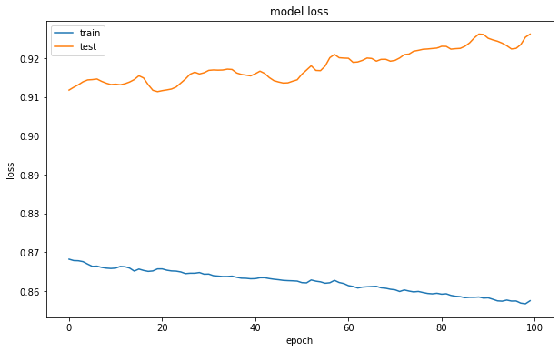

```python
# summarizing historical accuracy
# summarize history for loss
plt.plot(training_history.history['loss'])
plt.plot(training_history.history['val_loss'])
plt.title('model loss')
plt.ylabel('loss')
plt.xlabel('epoch')
plt.legend(['train', 'test'], loc='upper left')
plt.show()
```

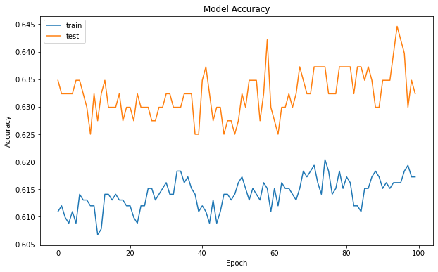

```python
# summarizing historical accuracy
plt.plot(training_history.history['accuracy'])
plt.plot(training_history.history['val_accuracy'])
plt.title('Model Accuracy')
plt.ylabel('Accuracy')
plt.xlabel('Epoch')
plt.legend(['train', 'test'], loc='upper left')
plt.show()
```

```python
## Hyper parameter tuning for improving the model (Changing the Adam Optimizer without adding any hidden layeer)
```

```python
## Creating the model
##initializing the Model
signal_model_3 = Sequential()

## input the first layer with input dimensions. Here the input parameters are 11

# The amount of nodes (dimensions) in hidden layer should be the average of input and output layers, in this case 6.
# This adds the input layer (by specifying input dimension) AND the first hidden layer (units)
#model_class.add(Dense(input_layer_size, activation='relu'))
signal_model_3.add(Dense(activation = 'relu', input_dim = input_layer_size, units=hidden_layer_size1, kernel_initializer='uniform'))

## Adding first hidden Layer
signal_model_3.add(Dense(input_layer_size, activation='relu',kernel_initializer='uniform'))

# Adding the output layer
# Notice that we do not need to specify input dim.
# we have an output of 6 node, which is the the desired dimensions of our output
# We use the softmax because we have multiclass classification problem
## setting softmax for output layer
signal_model_3.add(Dense(output_layer_size, activation='softmax'))
```

```python
# Compile the model
signal_model_3.compile(loss="categorical_crossentropy", metrics=["accuracy"], optimizer="adam")

# Fit the model
model_3_history=signal_model_3.fit(x=X_train_std, y=y_train, batch_size=20, epochs=100, validation_data=(X_test_std, y_test))
```

```python
scores = signal_model_3.evaluate(X_train_std, y_train, batch_size=30)
print("%s: %.2f%%" % (signal_model_3.metrics_names[1], scores[1]*100))
```

```
accuracy: 65.09%
```

E. Plot visuals as in Q3.C and share insights about difference observed in both the models. [3 Marks]

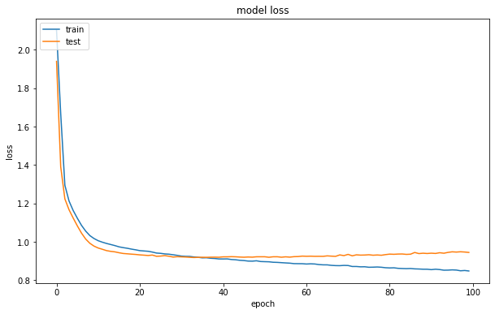

```python
# summarizing historical accuracy
# summarize history for loss
plt.plot(model_3_history.history['loss'])
plt.plot(model_3_history.history['val_loss'])
plt.title('model loss')
plt.ylabel('loss')
plt.xlabel('epoch')
plt.legend(['train', 'test'], loc='upper left')
plt.show()
```

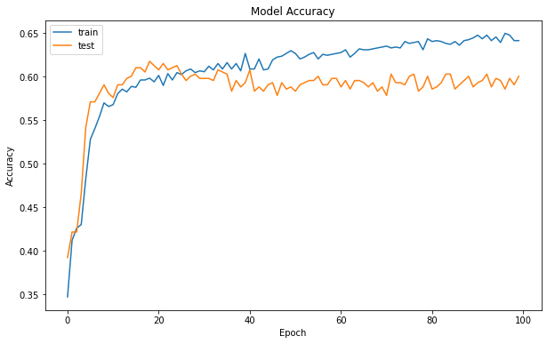

```python
# summarizing historical accuracy
plt.plot(model_3_history.history['accuracy'])
plt.plot(model_3_history.history['val_accuracy'])
plt.title('Model Accuracy')
plt.ylabel('Accuracy')
plt.xlabel('Epoch')
plt.legend(['train', 'test'], loc='upper left')
plt.show()
```

### Observation

# PART - B

- **DOMAIN:** Autonomous Vehicles
- **CONTEXT:** A Recognising multi-digit numbers in photographs captured at street level is an important component of modern-day map making. A classic example of a corpus of such street-level photographs is Google’s Street View imagery composed of hundreds of millions of geo-located 360-degree panoramic images.

The ability to automatically transcribe an address number from a geo-located patch of pixels and associate the transcribed number with a known street address helps pinpoint, with a high degree of accuracy, the location of the building it represents.

More broadly, recognising numbers in photographs is a problem of interest to the optical character recognition community. While OCR on constrained domains like document processing is well studied, arbitrary multi-character text recognition in photographs is still highly challenging. This difficulty arises due to the wide variability in the visual appearance of text in the wild on account of a large range of fonts, colours, styles, orientations, and character arrangements.

The recognition problem is further complicated by environmental factors such as lighting, shadows, specularity, and occlusions as well as by image acquisition factors such as resolution, motion, and focus blurs.

In this project, we will use the dataset with images centred around a single digit (many of the images do contain some distractors at the sides). Although we are taking a sample of the data which is simpler, it is more complex than MNIST because of the distractors.

- **DATA DESCRIPTION:** The SVHN is a real-world image dataset for developing machine learning and object recognition algorithms with the minimal requirement on data formatting but comes from a significantly harder, unsolved, real-world problem (recognising digits and numbers in natural scene images). SVHN is obtained from house numbers in Google Street View images.

Where the labels for each of this image are the prominent number in that image i.e. 2,6,7 and 4 respectively. The dataset has been provided in the form of h5py files. You can read about this file format here: https://docs.h5py.org/en/stable/ Acknowledgement: Yuval Netzer, Tao Wang, Adam Coates, Alessandro Bissacco, Bo Wu, Andrew Y. Ng Reading Digits in Natural Images with Unsupervised Feature Learning NIPS Workshop on Deep Learning and Unsupervised Feature Learning 2011. PDF http://ufldl.stanford.edu/housenumbers as the URL for this site.

Steps and tasks: [ Total Score: 30 Marks]

1. Data Import and Exploration [5 Marks]

A. Read the .h5 file and assign to a variable. [2 Marks]

#### importing required Libraries

```python
#Importing important libraries
import numpy as np
import pandas as pd
import matplotlib.pyplot as plt
%matplotlib inline

from sklearn.neighbors import KNeighborsClassifier
from sklearn.metrics import confusion_matrix,accuracy_score
from sklearn.metrics import classification_report

from keras.models import Sequential
from keras.utils.np_utils import to_categorical
from keras.layers import Activation, Dense
from keras.layers import BatchNormalization, Dropout
from keras import optimizers

import tensorflow as tf
import h5py
```

### Reading the .h5 file and assigning to variable

```python
auto_df=h5py.File("Autonomous_Vehicles_SVHN_single_grey1.h5",'r')
```

B. Print all the keys from the .h5 file. [1 Marks]

```python
auto_df.keys
```

```
<bound method MappingHDF5.keys of <HDF5 file "Autonomous_Vehicles_SVHN_single_grey1.h5" (mode r+)>>
```

```python
print(list(auto_df.keys()))
```

```
['X_test', 'X_train', 'X_val', 'y_test', 'y_train', 'y_val']
```

C. Split the data into X_train, X_test, Y_train, Y_test [2 Marks]

```python
#Load the training, testing, and validation data
X_train=auto_df['X_train'][:]
X_test=auto_df['X_test'][:]
X_val=auto_df['X_val'][:]
y_train=auto_df['y_train'][:]
y_test=auto_df['y_test'][:]
y_val=auto_df['y_val'][:]
```

2. Data Visualisation and preprocessing [13 Marks]

A.Print shape of all the 4 data split into x, y, train, test to verify if x & y is in sync. [1 Marks]

```python
print("Train Data shape")
print("---------------")
print(X_train.shape)
print(y_train.shape)
print("\n")

print("Test Data shape")
print("---------------")

print(X_test.shape)
print(y_test.shape)
print("\n")
print("Validation data shape")
print("---------------------")
print(X_val.shape)
print(y_val.shape)
```

```
Train Data shape
---------------
(42000, 32, 32)
(42000,)


Test Data shape
---------------
(18000, 32, 32)
(18000,)


Validation data shape
---------------------
(60000, 32, 32)
(60000,)
```

### Printing unique values of Target variable in train, validation and Test set

```python
print('\n')
print('y_train unique classes', np.unique(y_train))
print('y_val unique classes', np.unique(y_val))
print('y_train unique classes', np.unique(y_test))
```

```
y_train unique classes [0 1 2 3 4 5 6 7 8 9]
y_val unique classes [0 1 2 3 4 5 6 7 8 9]
y_train unique classes [0 1 2 3 4 5 6 7 8 9]
```

**Comments**:

```
*  It is been observed that all the X and Y values are in synch with All the Test, Train and validation data.
*  Training data has 42000 records, Testing set has 18000 records and validation set has 60000 records
*  The image is of 32*32 scale
```

B. Visualise first 10 images in train data and print its corresponding labels. [4 Marks]

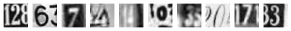

```
label for each of the above image: [2 6 7 4 4 0 3 0 7 3]
```

```python
# visualizing the first 10 images in the dataset and their labels
%matplotlib inline
import matplotlib.pyplot as plt
plt.figure(figsize=(10, 1))
for i in range(10):
    plt.subplot(1, 10, i+1)
    plt.imshow(X_train[i], cmap="gray")
    plt.axis('off')
plt.show()
print('label for each of the above image: %s' % (y_train[0:10]))
```

**Comments:**

```
* The image has more than one numbers, but label highlights prominent number
* Eg: 128 is labeled as 2 where 2 is prominent and 63 as 6 and so on
```

C. Reshape all the images with appropriate shape update the data in same variable. [3 Mark]

```python
from keras.utils import np_utils
```

```python
print("Training data X-- Shape :", X_train.shape)
print("Testing data X-- Shape :", X_test.shape)
print("Validation data X-- Shape :", X_val.shape)
```

```
Training data X-- Shape : (42000, 32, 32)
Testing data X-- Shape : (18000, 32, 32)
Validation data X-- Shape : (60000, 32, 32)
```

#### Reshaping to make it 1024 dimentsion

```python
X_train=np.array(X_train).reshape(X_train.shape[0],-1)
X_test=np.array(X_test).reshape(X_test.shape[0],-1)
X_val=np.array(X_val).reshape(X_val.shape[0],-1)
```

#### Verifying the shape and Datatype

```python
print("Training data X-- Shape :", X_train.shape,"and Data Type : ", X_train.dtype)
print("Testing data X-- Shape :", X_test.shape,"and Data Type : ", X_test.dtype)
print("Validation data X-- Shape :", X_val.shape,"and Data Type : ", X_val.dtype)
```

```
Training data X-- Shape : (42000, 1024) and Data Type :  float32
Testing data X-- Shape : (18000, 1024) and Data Type :  float32
Validation data X-- Shape : (60000, 1024) and Data Type :  float32
```

D. Normalise the images i.e. Normalise the pixel values. [2 Marks]

```python
print(X_train.min())
print(X_train.max())
print(X_test.min())
print(X_test.max())
print(X_val.min())
print(X_val.max())
```

```
0.0
254.9745
0.0
254.9745
0.0
254.9745
```

#### Normalizing by dividing the Maximum RGB value

```python
# # normalize inputs from 0-255 to 0-1
X_train = X_train / 255.0
X_test = X_test / 255.0
X_val=X_val/ 255.0
```

```python
X_test.max()
```

```
0.9999
```

```python
X_train.min()
```

```
0.0
```

E.Transform Labels into format acceptable by Neural Network [2 Marks]

```python
y_train.shape
```

```
(42000,)
```

#### Converting to categorical makes to one-hot encoded

```python
from tensorflow.keras.utils import to_categorical
# one hot encode outputs
y_train = to_categorical(y_train)
y_test = to_categorical(y_test)
y_val=to_categorical(y_val)
```

#### Printing the shape

```python
print("Training data X Shape :", X_train.shape)
print("Testing data X Shape :", X_test.shape)
print("Validation data X Shape :", X_val.shape)
```

```
Training data X Shape : (42000, 1024)
Testing data X Shape : (18000, 1024)
Validation data X Shape : (60000, 1024)
```

```python
print("Training data y Shape :", y_train.shape)
print("Testing data y Shape :", y_test.shape)
print("Validation data y Shape :", y_val.shape)
```

```
Training data y Shape : (42000, 10)
Testing data y Shape : (18000, 10)
Validation data y Shape : (60000, 10)
```

```python
y_test.shape
```

```
(18000, 10)
```

```python
y_train.shape
```

```
(42000, 10)
```

F. Print total Number of classes in the Dataset. [1 Marks]

```python
# no.of classes
num_classes = y_test.shape[1]
print("The number of classes in this dataset are:",num_classes)
```

```
The number of classes in this dataset are: 10
```

### Comments:

The number of classes are 10

3. Model Training & Evaluation using Neural Network [12 Marks]

A. Design a NeuralNetwork to train a classifier.[3Marks]

```python
# define model

from tensorflow.keras import optimizers
from tensorflow.keras.models import Sequential
from tensorflow.keras.layers import Dense, Flatten

def nn_model():
    # create model
    model = Sequential()
    model.add(Flatten())
    model.add(Dense(256, activation='relu')) ###Multiple Dense units with Relu activation
    model.add(Dense(64, activation='relu'))
    model.add(Dense(64, activation='relu'))
    model.add(Dense(32, activation='relu'))
    model.add(Dense(num_classes, activation='softmax'))
    return model
```

```python
# build the model
model = nn_model()
```

```python
y_val.shape[0]
```

```
60000
```

```python
y_val.shape
```

```
(60000, 10)
```

```python
## Set the SGD optimizer
```

```python
# Compile model
#sgd = optimizers.Adam(learning_rate=1e-3)
sgd = optimizers.SGD(learning_rate=1e-3, decay=1e-6, momentum=0.9)

### Loss function = Categorical cross entropy
model.compile(loss='categorical_crossentropy', optimizer=sgd, metrics=['accuracy'])
```

B.Train the classifier using previously designed Architecture (Use bestsuitable parameters). [3 Marks]

```python
### Fitting the model

training_history_sgd = model.fit(X_train, y_train, validation_data=(X_val, y_val), epochs=100, batch_size=300, verbose=2)
```

```
140/140 - 3s - loss: 2.3035 - accuracy: 0.1091 - val_loss: 2.2981 - val_accuracy: 0.1259 - 3s/epoch - 21ms/step
140/140 - 1s - loss: 2.2961 - accuracy: 0.1257 - val_loss: 2.2936 - val_accuracy: 0.1339 - 1s/epoch - 9ms/step
140/140 - 1s - loss: 2.2917 - accuracy: 0.1367 - val_loss: 2.2896 - val_accuracy: 0.1352 - 1s/epoch - 9ms/step
140/140 - 1s - loss: 2.2871 - accuracy: 0.1446 - val_loss: 2.2846 - val_accuracy: 0.1454 - 1s/epoch - 9ms/step
140/140 - 1s - loss: 2.2816 - accuracy: 0.1557 - val_loss: 2.2785 - val_accuracy: 0.1568 - 1s/epoch - 9ms/step
140/140 - 1s - loss: 2.2745 - accuracy: 0.1683 - val_loss: 2.2699 - val_accuracy: 0.1741 - 1s/epoch - 10ms/step
140/140 - 1s - loss: 2.2655 - accuracy: 0.1779 - val_loss: 2.2599 - val_accuracy: 0.1802 - 1s/epoch - 9ms/step
140/140 - 1s - loss: 2.2541 - accuracy: 0.1855 - val_loss: 2.2467 - val_accuracy: 0.1913 - 1s/epoch - 9ms/step
140/140 - 1s - loss: 2.2395 - accuracy: 0.1948 - val_loss: 2.2295 - val_accuracy: 0.2026 - 1s/epoch - 9ms/step
140/140 - 1s - loss: 2.2197 - accuracy: 0.2060 - val_loss: 2.2073 - val_accuracy: 0.2120 - 1s/epoch - 9ms/step
140/140 - 1s - loss: 2.1939 - accuracy: 0.2165 - val_loss: 2.1780 - val_accuracy: 0.2216 - 1s/epoch - 9ms/step
140/140 - 1s - loss: 2.1627 - accuracy: 0.2324 - val_loss: 2.1433 - val_accuracy: 0.2385 - 1s/epoch - 9ms/step
140/140 - 1s - loss: 2.1242 - accuracy: 0.2497 - val_loss: 2.0993 - val_accuracy: 0.2658 - 1s/epoch - 9ms/step
140/140 - 1s - loss: 2.0768 - accuracy: 0.2700 - val_loss: 2.0473 - val_accuracy: 0.2937 - 1s/epoch - 9ms/step
140/140 - 1s - loss: 2.0208 - accuracy: 0.2984 - val_loss: 1.9892 - val_accuracy: 0.3070 - 1s/epoch - 9ms/step
140/140 - 1s - loss: 1.9607 - accuracy: 0.3226 - val_loss: 1.9299 - val_accuracy: 0.3286 - 1s/epoch - 9ms/step
140/140 - 1s - loss: 1.9000 - accuracy: 0.3441 - val_loss: 1.8688 - val_accuracy: 0.3590 - 1s/epoch - 9ms/step
140/140 - 1s - loss: 1.8402 - accuracy: 0.3702 - val_loss: 1.8091 - val_accuracy: 0.3894 - 1s/epoch - 9ms/step
140/140 - 1s - loss: 1.7859 - accuracy: 0.3923 - val_loss: 1.7610 - val_accuracy: 0.4060 - 1s/epoch - 9ms/step
140/140 - 1s - loss: 1.7291 - accuracy: 0.4212 - val_loss: 1.6958 - val_accuracy: 0.4298 - 1s/epoch - 10ms/step
140/140 - 2s - loss: 1.6773 - accuracy: 0.4417 - val_loss: 1.6453 - val_accuracy: 0.4583 - 2s/epoch - 12ms/step
140/140 - 2s - loss: 1.6248 - accuracy: 0.4649 - val_loss: 1.5994 - val_accuracy: 0.4711 - 2s/epoch - 11ms/step
140/140 - 2s - loss: 1.5756 - accuracy: 0.4861 - val_loss: 1.5542 - val_accuracy: 0.4906 - 2s/epoch - 11ms/step
140/140 - 2s - loss: 1.5311 - accuracy: 0.5058 - val_loss: 1.5135 - val_accuracy: 0.5112 - 2s/epoch - 11ms/step
140/140 - 2s - loss: 1.4833 - accuracy: 0.5266 - val_loss: 1.4573 - val_accuracy: 0.5365 - 2s/epoch - 11ms/step
140/140 - 2s - loss: 1.4463 - accuracy: 0.5412 - val_loss: 1.4224 - val_accuracy: 0.5503 - 2s/epoch - 11ms/step
140/140 - 2s - loss: 1.4147 - accuracy: 0.5532 - val_loss: 1.3848 - val_accuracy: 0.5659 - 2s/epoch - 11ms/step
140/140 - 2s - loss: 1.3757 - accuracy: 0.5726 - val_loss: 1.3630 - val_accuracy: 0.5726 - 2s/epoch - 11ms/step
140/140 - 2s - loss: 1.3581 - accuracy: 0.5757 - val_loss: 1.3595 - val_accuracy: 0.5685 - 2s/epoch - 11ms/step
140/140 - 2s - loss: 1.3223 - accuracy: 0.5918 - val_loss: 1.2951 - val_accuracy: 0.6054 - 2s/epoch - 11ms/step
140/140 - 2s - loss: 1.2914 - accuracy: 0.6030 - val_loss: 1.2727 - val_accuracy: 0.6080 - 2s/epoch - 11ms/step
140/140 - 2s - loss: 1.2705 - accuracy: 0.6090 - val_loss: 1.2692 - val_accuracy: 0.6037 - 2s/epoch - 11ms/step
140/140 - 2s - loss: 1.2447 - accuracy: 0.6181 - val_loss: 1.2354 - val_accuracy: 0.6181 - 2s/epoch - 11ms/step
140/140 - 2s - loss: 1.2250 - accuracy: 0.6252 - val_loss: 1.1997 - val_accuracy: 0.6371 - 2s/epoch - 12ms/step
140/140 - 2s - loss: 1.2005 - accuracy: 0.6335 - val_loss: 1.1847 - val_accuracy: 0.6378 - 2s/epoch - 12ms/step
140/140 - 1s - loss: 1.1803 - accuracy: 0.6394 - val_loss: 1.1715 - val_accuracy: 0.6450 - 1s/epoch - 11ms/step
140/140 - 1s - loss: 1.1663 - accuracy: 0.6444 - val_loss: 1.1590 - val_accuracy: 0.6469 - 1s/epoch - 11ms/step
140/140 - 2s - loss: 1.1538 - accuracy: 0.6471 - val_loss: 1.1680 - val_accuracy: 0.6408 - 2s/epoch - 11ms/step
140/140 - 1s - loss: 1.1370 - accuracy: 0.6540 - val_loss: 1.1253 - val_accuracy: 0.6590 - 1s/epoch - 11ms/step
140/140 - 2s - loss: 1.1190 - accuracy: 0.6590 - val_loss: 1.1485 - val_accuracy: 0.6495 - 2s/epoch - 11ms/step
```

[output cut: 45 more lines]

```
140/140 - 1s - loss: 0.7448 - accuracy: 0.7740 - val_loss: 0.7618 - val_accuracy: 0.7690 - 1s/epoch - 11ms/step
140/140 - 1s - loss: 0.7389 - accuracy: 0.7755 - val_loss: 0.7406 - val_accuracy: 0.7781 - 1s/epoch - 11ms/step
140/140 - 1s - loss: 0.7289 - accuracy: 0.7790 - val_loss: 0.7381 - val_accuracy: 0.7793 - 1s/epoch - 11ms/step
140/140 - 2s - loss: 0.7245 - accuracy: 0.7823 - val_loss: 0.8168 - val_accuracy: 0.7560 - 2s/epoch - 12ms/step
140/140 - 2s - loss: 0.7308 - accuracy: 0.7784 - val_loss: 0.8242 - val_accuracy: 0.7531 - 2s/epoch - 12ms/step
140/140 - 2s - loss: 0.7151 - accuracy: 0.7836 - val_loss: 0.7343 - val_accuracy: 0.7810 - 2s/epoch - 12ms/step
140/140 - 2s - loss: 0.7160 - accuracy: 0.7833 - val_loss: 0.7182 - val_accuracy: 0.7839 - 2s/epoch - 12ms/step
140/140 - 2s - loss: 0.7027 - accuracy: 0.7887 - val_loss: 0.7143 - val_accuracy: 0.7872 - 2s/epoch - 11ms/step
140/140 - 2s - loss: 0.6987 - accuracy: 0.7890 - val_loss: 0.7104 - val_accuracy: 0.7877 - 2s/epoch - 11ms/step
140/140 - 2s - loss: 0.6997 - accuracy: 0.7868 - val_loss: 0.6995 - val_accuracy: 0.7902 - 2s/epoch - 11ms/step
140/140 - 2s - loss: 0.6993 - accuracy: 0.7871 - val_loss: 0.7036 - val_accuracy: 0.7899 - 2s/epoch - 11ms/step
140/140 - 2s - loss: 0.6832 - accuracy: 0.7932 - val_loss: 0.6960 - val_accuracy: 0.7923 - 2s/epoch - 11ms/step
140/140 - 2s - loss: 0.6766 - accuracy: 0.7943 - val_loss: 0.7047 - val_accuracy: 0.7893 - 2s/epoch - 11ms/step
140/140 - 2s - loss: 0.6722 - accuracy: 0.7973 - val_loss: 0.7030 - val_accuracy: 0.7900 - 2s/epoch - 11ms/step
140/140 - 2s - loss: 0.6725 - accuracy: 0.7957 - val_loss: 0.6877 - val_accuracy: 0.7939 - 2s/epoch - 11ms/step
```

C. Evaluate performance of the model with appropriate metrics. [2 Marks]

```python
# Final evaluation of the model
scores = model.evaluate(X_test, y_test, verbose=0)
print("Loss:", scores[0])
print("Accuracy:", scores[1])
```

```
Loss: 0.7652205228805542
Accuracy: 0.7746111154556274
```

```python
## Train accuracy
```

```python
# evaluation of the model for train set
scores = model.evaluate(X_train, y_train, verbose=0)
print("Loss:", scores[0])
print("Accuracy:", scores[1])
```

```
Loss: 0.6544567942619324
Accuracy: 0.8021190762519836
```

D.Plot the training loss,validation loss vs number of epochs and trainingaccuracy,validationaccuracy vs number of epochs plot and write your observations on the same.

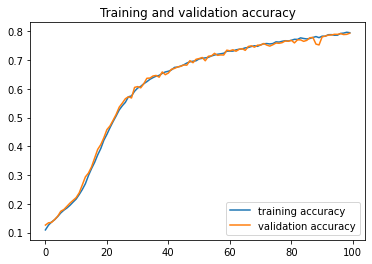

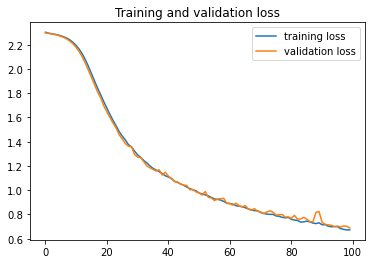

```python
accuracy      = training_history_sgd.history['accuracy']
val_accuracy  = training_history_sgd.history['val_accuracy']
loss     = training_history_sgd.history['loss']
val_loss = training_history_sgd.history['val_loss']

epochs   = range(len(accuracy)) # Get number of epochs

plt.plot  ( epochs, accuracy, label = 'training accuracy' )
plt.plot  ( epochs, val_accuracy, label = 'validation accuracy' )
plt.title ('Training and validation accuracy')
plt.legend(loc = 'lower right')
plt.figure()

plt.plot  ( epochs, loss, label = 'training loss' )
plt.plot  ( epochs, val_loss, label = 'validation loss' )
plt.legend(loc = 'upper right')
plt.title ('Training and validation loss'   )
```

```python
print(X_train.shape)
print(y_train.shape)
print(X_val.shape)
print(y_val.shape)
```

```
(42000, 1024)
(42000, 10)
(60000, 1024)
(60000, 10)
```

```
Predicted label: 8
Softmax Outputs: [[1.6832151e-02 8.6933447e-05 1.5713709e-03 1.3060752e-02 7.1193941e-04
  4.0591769e-03 6.0988134e-03 8.4079380e-05 7.8119659e-01 1.7629817e-01]]
1.0
```

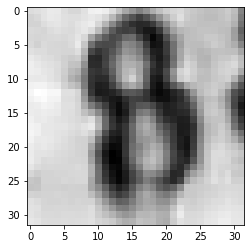

```python
import matplotlib.pyplot as plt
%matplotlib inline
plt.imshow(X_test[10].reshape(32, 32), cmap='gray')
y_pred = model.predict(X_test[10].reshape(1, 32, 32, 1))
print("Predicted label:", y_pred.argmax())
print("Softmax Outputs:", y_pred)
print(y_pred.sum())
```

```
Predicted label: 8
Softmax Outputs: [[2.68928943e-05 2.38046471e-08 1.10022675e-05 1.60322834e-05
  2.69282609e-05 8.92115713e-06 1.16296636e-03 3.43349504e-09
  9.98164713e-01 5.82636683e-04]]
1.0000001
```

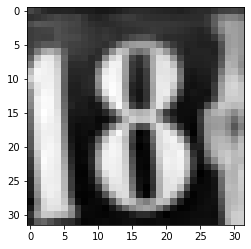

```python
import matplotlib.pyplot as plt
%matplotlib inline
plt.imshow(X_test[6666].reshape(32, 32), cmap='gray')
y_pred = model.predict(X_test[6666].reshape(1, 32, 32, 1))
print("Predicted label:", y_pred.argmax())
print("Softmax Outputs:", y_pred)
print(y_pred.sum())
```

```
Predicted label: 1
Softmax Outputs: [[9.2118280e-05 4.9862757e-01 2.1689165e-01 6.7037374e-02 5.7684314e-03
  1.0979514e-02 1.0742889e-03 1.9129613e-01 4.0202951e-03 4.2126784e-03]]
1.0
```

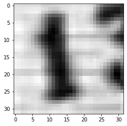

```python
import matplotlib.pyplot as plt
%matplotlib inline
plt.imshow(X_test[6].reshape(32, 32), cmap='gray')
y_pred = model.predict(X_test[6].reshape(1, 32, 32, 1))
print("Predicted label:", y_pred.argmax())
print("Softmax Outputs:", y_pred)
print(y_pred.sum())
```

```
Predicted label: 6
Softmax Outputs: [[1.8443586e-04 1.3789891e-04 9.2405324e-05 3.1519709e-03 1.8705210e-03
  2.2902000e-01 4.1437313e-01 2.2346248e-05 3.4380892e-01 7.3383260e-03]]
0.99999994
```

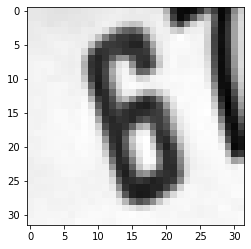

```python
import matplotlib.pyplot as plt
%matplotlib inline
plt.imshow(X_test[400].reshape(32, 32), cmap='gray')
y_pred = model.predict(X_test[400].reshape(1, 32, 32, 1))
print("Predicted label:", y_pred.argmax())
print("Softmax Outputs:", y_pred)
print(y_pred.sum())
```

```python
#prediction = model.predict(X_val[0])[0])

predictions = (model.predict(X_test) > 0.5).astype("int32")
```

```python
print(predictions)
```

```
[[0 0 0 ... 0 0 0]
 [0 0 0 ... 1 0 0]
 [0 0 1 ... 0 0 0]
 ...
 [0 0 0 ... 1 0 0]
 [0 0 0 ... 0 0 1]
 [0 0 1 ... 0 0 0]]
```

```python
np.argmax(predictions)
```

```
17
```

```python
print(X_val.shape)
```

```
(60000, 1024)
```

```python
## Creating second class
from tensorflow.keras import regularizers, optimizers
```

```python
def train_and_test_loop(iterations, lr, Lambda, verb=True):

    ## hyperparameters
    iterations = iterations
    learning_rate = lr
    hidden_nodes = 256
    output_nodes = 10

  ##  model = Sequential()
  ##  model.add(Dense(hidden_nodes, input_shape=(784,), activation='relu'))
   ## model.add(Dense(hidden_nodes, activation='relu'))
  ##  model.add(Dense(output_nodes, activation='softmax', kernel_regularizer=regularizers.l2(Lambda)))


    second_model = Sequential()
    second_model.add(Flatten())
    second_model.add(Dense(256, input_shape=(X_train.shape[1],),activation='relu')) ###Multiple Dense units with Relu activation
    second_model.add(Dense(64, activation='relu'))
    #second_model.add(Dense(64, activation='relu'))
    second_model.add(Dense(32, activation='relu'))
    second_model.add(Dense(num_classes, activation='softmax',kernel_regularizer=regularizers.l2(Lambda)))

    sgd = optimizers.SGD(learning_rate=learning_rate, decay=1e-6, momentum=0.9)
    # Compile model
    second_model.compile(loss='categorical_crossentropy', optimizer=sgd, metrics=['accuracy'])

    # Fit the model
    second_model.fit(X_train, y_train, epochs=iterations, batch_size=1000, verbose= 1)
    score = second_model.evaluate(X_train, y_train, verbose=0)

    return score
```

One of the hyperparameters in the optimizer is the **learning rate** We will also tune the learning rate. Learning rate controls the step size for a model to reach the minimum loss function. A higher learning rate makes the model learn faster, but it may miss the minimum loss function and only reach the surrounding of it. A lower learning rate gives a better chance to find a minimum loss function. As a tradeoff lower learning rate needs higher epochs, or more time and memory capacity resources

```python
lr = 0.00001
Lambda = 0
train_and_test_loop(1, lr, Lambda)
```

```
[2.346914291381836, 0.10778571665287018]
```

**Observation**:

```
Second model did not give accuracy
```

### Build the third model with Adam Optimizer

```python
# build the model
model_3 = nn_model()
```

```python
#sgd = optimizers.SGD(learning_rate=1e-3, decay=1e-6, momentum=0.9)
opt_alpha1 =optimizers.Adam(learning_rate=1e-3)

# Compile modeloptimizers.Adam(learning_rate=1e-3)
model_3.compile(loss='categorical_crossentropy', optimizer=opt_alpha1, metrics=['accuracy'])
```

```python
### Fitting the model

training_history_adam = model_3.fit(X_train, y_train, validation_data=(X_val, y_val), epochs=100, batch_size=300, verbose=2)
```

```
140/140 - 3s - loss: 2.3008 - accuracy: 0.1089 - val_loss: 2.2584 - val_accuracy: 0.1360 - 3s/epoch - 19ms/step
140/140 - 1s - loss: 2.0460 - accuracy: 0.2634 - val_loss: 1.7896 - val_accuracy: 0.3726 - 1s/epoch - 9ms/step
140/140 - 1s - loss: 1.6128 - accuracy: 0.4517 - val_loss: 1.5230 - val_accuracy: 0.4739 - 1s/epoch - 9ms/step
140/140 - 1s - loss: 1.4616 - accuracy: 0.5076 - val_loss: 1.4821 - val_accuracy: 0.4928 - 1s/epoch - 9ms/step
140/140 - 1s - loss: 1.3888 - accuracy: 0.5400 - val_loss: 1.3524 - val_accuracy: 0.5545 - 1s/epoch - 9ms/step
140/140 - 1s - loss: 1.3190 - accuracy: 0.5685 - val_loss: 1.2561 - val_accuracy: 0.5950 - 1s/epoch - 9ms/step
140/140 - 1s - loss: 1.2687 - accuracy: 0.5895 - val_loss: 1.2251 - val_accuracy: 0.6064 - 1s/epoch - 9ms/step
140/140 - 1s - loss: 1.2259 - accuracy: 0.6059 - val_loss: 1.1946 - val_accuracy: 0.6175 - 1s/epoch - 9ms/step
140/140 - 1s - loss: 1.1781 - accuracy: 0.6243 - val_loss: 1.1557 - val_accuracy: 0.6322 - 1s/epoch - 9ms/step
140/140 - 1s - loss: 1.1423 - accuracy: 0.6383 - val_loss: 1.1151 - val_accuracy: 0.6462 - 1s/epoch - 9ms/step
140/140 - 1s - loss: 1.1262 - accuracy: 0.6419 - val_loss: 1.1069 - val_accuracy: 0.6471 - 1s/epoch - 9ms/step
140/140 - 1s - loss: 1.0944 - accuracy: 0.6539 - val_loss: 1.0960 - val_accuracy: 0.6536 - 1s/epoch - 9ms/step
140/140 - 1s - loss: 1.0789 - accuracy: 0.6588 - val_loss: 1.0783 - val_accuracy: 0.6597 - 1s/epoch - 10ms/step
140/140 - 1s - loss: 1.0521 - accuracy: 0.6707 - val_loss: 1.0557 - val_accuracy: 0.6664 - 1s/epoch - 9ms/step
140/140 - 1s - loss: 1.0480 - accuracy: 0.6714 - val_loss: 1.0990 - val_accuracy: 0.6454 - 1s/epoch - 10ms/step
140/140 - 1s - loss: 1.0159 - accuracy: 0.6805 - val_loss: 1.0318 - val_accuracy: 0.6713 - 1s/epoch - 9ms/step
140/140 - 1s - loss: 1.0031 - accuracy: 0.6857 - val_loss: 1.0149 - val_accuracy: 0.6817 - 1s/epoch - 9ms/step
140/140 - 1s - loss: 0.9947 - accuracy: 0.6887 - val_loss: 0.9834 - val_accuracy: 0.6917 - 1s/epoch - 9ms/step
140/140 - 1s - loss: 0.9729 - accuracy: 0.6960 - val_loss: 1.0096 - val_accuracy: 0.6834 - 1s/epoch - 9ms/step
140/140 - 1s - loss: 0.9692 - accuracy: 0.6959 - val_loss: 0.9678 - val_accuracy: 0.6991 - 1s/epoch - 9ms/step
140/140 - 2s - loss: 0.9481 - accuracy: 0.7043 - val_loss: 0.9899 - val_accuracy: 0.6868 - 2s/epoch - 11ms/step
140/140 - 2s - loss: 0.9320 - accuracy: 0.7092 - val_loss: 0.9086 - val_accuracy: 0.7176 - 2s/epoch - 11ms/step
140/140 - 1s - loss: 0.9140 - accuracy: 0.7170 - val_loss: 0.9179 - val_accuracy: 0.7130 - 1s/epoch - 11ms/step
140/140 - 2s - loss: 0.9004 - accuracy: 0.7195 - val_loss: 0.8706 - val_accuracy: 0.7315 - 2s/epoch - 11ms/step
140/140 - 2s - loss: 0.8736 - accuracy: 0.7293 - val_loss: 0.8863 - val_accuracy: 0.7233 - 2s/epoch - 11ms/step
140/140 - 2s - loss: 0.8698 - accuracy: 0.7301 - val_loss: 0.8815 - val_accuracy: 0.7264 - 2s/epoch - 13ms/step
140/140 - 2s - loss: 0.8613 - accuracy: 0.7311 - val_loss: 0.8419 - val_accuracy: 0.7398 - 2s/epoch - 13ms/step
140/140 - 2s - loss: 0.8356 - accuracy: 0.7398 - val_loss: 0.8499 - val_accuracy: 0.7352 - 2s/epoch - 13ms/step
140/140 - 2s - loss: 0.8292 - accuracy: 0.7439 - val_loss: 0.8131 - val_accuracy: 0.7499 - 2s/epoch - 12ms/step
140/140 - 2s - loss: 0.8068 - accuracy: 0.7512 - val_loss: 0.8256 - val_accuracy: 0.7462 - 2s/epoch - 13ms/step
140/140 - 2s - loss: 0.7952 - accuracy: 0.7541 - val_loss: 0.7889 - val_accuracy: 0.7579 - 2s/epoch - 12ms/step
140/140 - 2s - loss: 0.7937 - accuracy: 0.7542 - val_loss: 0.7655 - val_accuracy: 0.7654 - 2s/epoch - 13ms/step
140/140 - 2s - loss: 0.7885 - accuracy: 0.7571 - val_loss: 0.8123 - val_accuracy: 0.7501 - 2s/epoch - 12ms/step
140/140 - 2s - loss: 0.7635 - accuracy: 0.7661 - val_loss: 0.7572 - val_accuracy: 0.7695 - 2s/epoch - 12ms/step
140/140 - 2s - loss: 0.7562 - accuracy: 0.7664 - val_loss: 0.7443 - val_accuracy: 0.7741 - 2s/epoch - 13ms/step
140/140 - 2s - loss: 0.7518 - accuracy: 0.7675 - val_loss: 0.7396 - val_accuracy: 0.7751 - 2s/epoch - 13ms/step
140/140 - 2s - loss: 0.7412 - accuracy: 0.7702 - val_loss: 0.7596 - val_accuracy: 0.7662 - 2s/epoch - 13ms/step
140/140 - 2s - loss: 0.7386 - accuracy: 0.7721 - val_loss: 0.7480 - val_accuracy: 0.7712 - 2s/epoch - 13ms/step
140/140 - 2s - loss: 0.7163 - accuracy: 0.7800 - val_loss: 0.7326 - val_accuracy: 0.7745 - 2s/epoch - 12ms/step
140/140 - 2s - loss: 0.7201 - accuracy: 0.7793 - val_loss: 0.7175 - val_accuracy: 0.7828 - 2s/epoch - 13ms/step
```

[output cut: 45 more lines]

```
140/140 - 2s - loss: 0.5117 - accuracy: 0.8412 - val_loss: 0.5553 - val_accuracy: 0.8310 - 2s/epoch - 11ms/step
140/140 - 2s - loss: 0.5102 - accuracy: 0.8404 - val_loss: 0.5505 - val_accuracy: 0.8339 - 2s/epoch - 11ms/step
140/140 - 2s - loss: 0.5108 - accuracy: 0.8406 - val_loss: 0.5421 - val_accuracy: 0.8369 - 2s/epoch - 12ms/step
140/140 - 2s - loss: 0.5018 - accuracy: 0.8439 - val_loss: 0.5640 - val_accuracy: 0.8284 - 2s/epoch - 11ms/step
140/140 - 2s - loss: 0.5072 - accuracy: 0.8422 - val_loss: 0.5530 - val_accuracy: 0.8336 - 2s/epoch - 11ms/step
140/140 - 2s - loss: 0.4959 - accuracy: 0.8448 - val_loss: 0.5357 - val_accuracy: 0.8378 - 2s/epoch - 11ms/step
140/140 - 2s - loss: 0.4984 - accuracy: 0.8454 - val_loss: 0.5768 - val_accuracy: 0.8261 - 2s/epoch - 11ms/step
140/140 - 1s - loss: 0.4993 - accuracy: 0.8437 - val_loss: 0.5261 - val_accuracy: 0.8409 - 1s/epoch - 11ms/step
140/140 - 1s - loss: 0.5020 - accuracy: 0.8423 - val_loss: 0.5784 - val_accuracy: 0.8237 - 1s/epoch - 11ms/step
140/140 - 1s - loss: 0.4968 - accuracy: 0.8454 - val_loss: 0.6001 - val_accuracy: 0.8183 - 1s/epoch - 11ms/step
140/140 - 2s - loss: 0.4961 - accuracy: 0.8457 - val_loss: 0.5525 - val_accuracy: 0.8317 - 2s/epoch - 11ms/step
140/140 - 1s - loss: 0.4913 - accuracy: 0.8455 - val_loss: 0.5385 - val_accuracy: 0.8368 - 1s/epoch - 11ms/step
140/140 - 2s - loss: 0.4811 - accuracy: 0.8497 - val_loss: 0.5337 - val_accuracy: 0.8385 - 2s/epoch - 11ms/step
140/140 - 1s - loss: 0.4843 - accuracy: 0.8490 - val_loss: 0.5404 - val_accuracy: 0.8370 - 1s/epoch - 11ms/step
140/140 - 1s - loss: 0.4899 - accuracy: 0.8480 - val_loss: 0.5260 - val_accuracy: 0.8411 - 1s/epoch - 11ms/step
```

```python
# Final evaluation of the model
scores = model_3.evaluate(X_test, y_test, verbose=0)
print("Loss:", scores[0])
print("Accuracy:", scores[1])
```

```
Loss: 0.6748959422111511
Accuracy: 0.8052777647972107
```

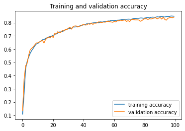

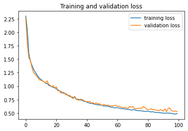

```python
accuracy      = training_history_adam.history['accuracy']
val_accuracy  = training_history_adam.history['val_accuracy']
loss     = training_history_adam.history['loss']
val_loss = training_history_adam.history['val_loss']

epochs   = range(len(accuracy)) # Get number of epochs

plt.plot  ( epochs, accuracy, label = 'training accuracy' )
plt.plot  ( epochs, val_accuracy, label = 'validation accuracy' )
plt.title ('Training and validation accuracy')
plt.legend(loc = 'lower right')
plt.figure()

plt.plot  ( epochs, loss, label = 'training loss' )
plt.plot  ( epochs, val_loss, label = 'validation loss' )
plt.legend(loc = 'upper right')
plt.title ('Training and validation loss'   )
```

**Observation**: Among all the 3 models the model3 with Adam optimizer gives better accuracy of 80% compared to other two models. Let us try other parameter change to see any further improvement is possible.

#### Changing the Learning Rate

```python
# build the model
model_4 = nn_model()
#sgd = optimizers.SGD(learning_rate=1e-3, decay=1e-6, momentum=0.9)
opt_alpha2 =optimizers.Adam(learning_rate=1e-4)

# Compile modeloptimizers.Adam(learning_rate=1e-4)
model_4.compile(loss='categorical_crossentropy', optimizer=opt_alpha2, metrics=['accuracy'])

## Fit the model
training_history_adam2 = model_4.fit(X_train, y_train, validation_data=(X_val, y_val), epochs=200, batch_size=300, verbose=2)
```

```
140/140 - 2s - loss: 2.2907 - accuracy: 0.1405 - val_loss: 2.2663 - val_accuracy: 0.1845 - 2s/epoch - 15ms/step
140/140 - 1s - loss: 2.2126 - accuracy: 0.2463 - val_loss: 2.1419 - val_accuracy: 0.2873 - 1s/epoch - 9ms/step
140/140 - 1s - loss: 2.0415 - accuracy: 0.3356 - val_loss: 1.9427 - val_accuracy: 0.3736 - 1s/epoch - 9ms/step
140/140 - 1s - loss: 1.8406 - accuracy: 0.4117 - val_loss: 1.7440 - val_accuracy: 0.4508 - 1s/epoch - 9ms/step
140/140 - 1s - loss: 1.6727 - accuracy: 0.4776 - val_loss: 1.6087 - val_accuracy: 0.4999 - 1s/epoch - 9ms/step
140/140 - 1s - loss: 1.5533 - accuracy: 0.5177 - val_loss: 1.4981 - val_accuracy: 0.5392 - 1s/epoch - 9ms/step
140/140 - 1s - loss: 1.4694 - accuracy: 0.5464 - val_loss: 1.4279 - val_accuracy: 0.5588 - 1s/epoch - 9ms/step
140/140 - 1s - loss: 1.4076 - accuracy: 0.5644 - val_loss: 1.3692 - val_accuracy: 0.5810 - 1s/epoch - 9ms/step
140/140 - 1s - loss: 1.3571 - accuracy: 0.5805 - val_loss: 1.3302 - val_accuracy: 0.5927 - 1s/epoch - 9ms/step
140/140 - 1s - loss: 1.3161 - accuracy: 0.5951 - val_loss: 1.3012 - val_accuracy: 0.5992 - 1s/epoch - 9ms/step
140/140 - 1s - loss: 1.2805 - accuracy: 0.6057 - val_loss: 1.2551 - val_accuracy: 0.6156 - 1s/epoch - 9ms/step
140/140 - 1s - loss: 1.2502 - accuracy: 0.6150 - val_loss: 1.2321 - val_accuracy: 0.6242 - 1s/epoch - 9ms/step
140/140 - 1s - loss: 1.2179 - accuracy: 0.6290 - val_loss: 1.2166 - val_accuracy: 0.6258 - 1s/epoch - 9ms/step
140/140 - 1s - loss: 1.1913 - accuracy: 0.6365 - val_loss: 1.1636 - val_accuracy: 0.6507 - 1s/epoch - 9ms/step
140/140 - 1s - loss: 1.1614 - accuracy: 0.6498 - val_loss: 1.1464 - val_accuracy: 0.6566 - 1s/epoch - 9ms/step
140/140 - 1s - loss: 1.1389 - accuracy: 0.6572 - val_loss: 1.1223 - val_accuracy: 0.6655 - 1s/epoch - 9ms/step
140/140 - 1s - loss: 1.1178 - accuracy: 0.6632 - val_loss: 1.1032 - val_accuracy: 0.6704 - 1s/epoch - 9ms/step
140/140 - 1s - loss: 1.0971 - accuracy: 0.6716 - val_loss: 1.0968 - val_accuracy: 0.6697 - 1s/epoch - 10ms/step
140/140 - 1s - loss: 1.0763 - accuracy: 0.6771 - val_loss: 1.0692 - val_accuracy: 0.6805 - 1s/epoch - 9ms/step
140/140 - 2s - loss: 1.0589 - accuracy: 0.6827 - val_loss: 1.0456 - val_accuracy: 0.6884 - 2s/epoch - 11ms/step
140/140 - 2s - loss: 1.0382 - accuracy: 0.6881 - val_loss: 1.0397 - val_accuracy: 0.6891 - 2s/epoch - 12ms/step
140/140 - 2s - loss: 1.0203 - accuracy: 0.6962 - val_loss: 1.0209 - val_accuracy: 0.6948 - 2s/epoch - 11ms/step
140/140 - 2s - loss: 1.0070 - accuracy: 0.6996 - val_loss: 1.0082 - val_accuracy: 0.6988 - 2s/epoch - 11ms/step
140/140 - 1s - loss: 0.9901 - accuracy: 0.7062 - val_loss: 0.9855 - val_accuracy: 0.7064 - 1s/epoch - 11ms/step
140/140 - 1s - loss: 0.9717 - accuracy: 0.7108 - val_loss: 0.9823 - val_accuracy: 0.7074 - 1s/epoch - 11ms/step
140/140 - 2s - loss: 0.9605 - accuracy: 0.7127 - val_loss: 0.9644 - val_accuracy: 0.7131 - 2s/epoch - 11ms/step
140/140 - 1s - loss: 0.9481 - accuracy: 0.7163 - val_loss: 0.9526 - val_accuracy: 0.7162 - 1s/epoch - 11ms/step
140/140 - 1s - loss: 0.9351 - accuracy: 0.7214 - val_loss: 0.9268 - val_accuracy: 0.7259 - 1s/epoch - 11ms/step
140/140 - 1s - loss: 0.9195 - accuracy: 0.7246 - val_loss: 0.9287 - val_accuracy: 0.7262 - 1s/epoch - 11ms/step
140/140 - 2s - loss: 0.9107 - accuracy: 0.7290 - val_loss: 0.9228 - val_accuracy: 0.7247 - 2s/epoch - 11ms/step
140/140 - 2s - loss: 0.8951 - accuracy: 0.7334 - val_loss: 0.8905 - val_accuracy: 0.7373 - 2s/epoch - 11ms/step
140/140 - 2s - loss: 0.8855 - accuracy: 0.7364 - val_loss: 0.8943 - val_accuracy: 0.7367 - 2s/epoch - 11ms/step
140/140 - 2s - loss: 0.8781 - accuracy: 0.7386 - val_loss: 0.8891 - val_accuracy: 0.7371 - 2s/epoch - 11ms/step
140/140 - 2s - loss: 0.8650 - accuracy: 0.7418 - val_loss: 0.8677 - val_accuracy: 0.7433 - 2s/epoch - 11ms/step
140/140 - 2s - loss: 0.8572 - accuracy: 0.7444 - val_loss: 0.8648 - val_accuracy: 0.7434 - 2s/epoch - 11ms/step
140/140 - 2s - loss: 0.8492 - accuracy: 0.7465 - val_loss: 0.8508 - val_accuracy: 0.7481 - 2s/epoch - 11ms/step
140/140 - 2s - loss: 0.8365 - accuracy: 0.7502 - val_loss: 0.8441 - val_accuracy: 0.7483 - 2s/epoch - 11ms/step
140/140 - 1s - loss: 0.8307 - accuracy: 0.7528 - val_loss: 0.8358 - val_accuracy: 0.7499 - 1s/epoch - 11ms/step
140/140 - 2s - loss: 0.8227 - accuracy: 0.7545 - val_loss: 0.8215 - val_accuracy: 0.7575 - 2s/epoch - 11ms/step
140/140 - 1s - loss: 0.8127 - accuracy: 0.7570 - val_loss: 0.8241 - val_accuracy: 0.7563 - 1s/epoch - 11ms/step
```

[output cut: 145 more lines]

```
140/140 - 2s - loss: 0.4273 - accuracy: 0.8712 - val_loss: 0.4827 - val_accuracy: 0.8611 - 2s/epoch - 11ms/step
140/140 - 2s - loss: 0.4208 - accuracy: 0.8731 - val_loss: 0.4932 - val_accuracy: 0.8573 - 2s/epoch - 11ms/step
140/140 - 1s - loss: 0.4168 - accuracy: 0.8737 - val_loss: 0.4788 - val_accuracy: 0.8620 - 1s/epoch - 11ms/step
140/140 - 2s - loss: 0.4175 - accuracy: 0.8747 - val_loss: 0.4794 - val_accuracy: 0.8605 - 2s/epoch - 11ms/step
140/140 - 2s - loss: 0.4209 - accuracy: 0.8722 - val_loss: 0.4814 - val_accuracy: 0.8608 - 2s/epoch - 11ms/step
140/140 - 2s - loss: 0.4135 - accuracy: 0.8761 - val_loss: 0.4836 - val_accuracy: 0.8600 - 2s/epoch - 11ms/step
140/140 - 2s - loss: 0.4137 - accuracy: 0.8759 - val_loss: 0.4843 - val_accuracy: 0.8603 - 2s/epoch - 11ms/step
140/140 - 2s - loss: 0.4157 - accuracy: 0.8751 - val_loss: 0.4765 - val_accuracy: 0.8636 - 2s/epoch - 11ms/step
140/140 - 2s - loss: 0.4112 - accuracy: 0.8757 - val_loss: 0.4786 - val_accuracy: 0.8627 - 2s/epoch - 11ms/step
140/140 - 2s - loss: 0.4092 - accuracy: 0.8763 - val_loss: 0.4742 - val_accuracy: 0.8632 - 2s/epoch - 11ms/step
140/140 - 2s - loss: 0.4158 - accuracy: 0.8741 - val_loss: 0.4702 - val_accuracy: 0.8654 - 2s/epoch - 11ms/step
140/140 - 2s - loss: 0.4100 - accuracy: 0.8765 - val_loss: 0.4715 - val_accuracy: 0.8636 - 2s/epoch - 12ms/step
140/140 - 2s - loss: 0.4056 - accuracy: 0.8781 - val_loss: 0.4693 - val_accuracy: 0.8646 - 2s/epoch - 12ms/step
140/140 - 2s - loss: 0.4099 - accuracy: 0.8765 - val_loss: 0.4662 - val_accuracy: 0.8653 - 2s/epoch - 13ms/step
140/140 - 2s - loss: 0.4100 - accuracy: 0.8768 - val_loss: 0.4740 - val_accuracy: 0.8627 - 2s/epoch - 11ms/step
```

```python
# Final evaluation of the model
scores = model_4.evaluate(X_test, y_test, verbose=0)
print("Loss:", scores[0])
print("Accuracy:", scores[1])
```

```
Loss: 0.6448935866355896
Accuracy: 0.824833333492279
```

Comments: Accuracy Increased to 82.48%

```python
# build the model
model_5 = nn_model()
#sgd = optimizers.SGD(learning_rate=1e-3, decay=1e-6, momentum=0.9)
opt_alpha3 =optimizers.Adam(learning_rate=1e-2)

# Compile modeloptimizers.Adam(learning_rate=1e-4)
model_5.compile(loss='categorical_crossentropy', optimizer=opt_alpha3, metrics=['accuracy'])

## Fit the model
training_history_adam3 = model_5.fit(X_train, y_train, validation_data=(X_val, y_val), epochs=100, batch_size=300, verbose=2)
```

```
140/140 - 2s - loss: 2.3503 - accuracy: 0.0988 - val_loss: 2.3028 - val_accuracy: 0.1000 - 2s/epoch - 16ms/step
140/140 - 1s - loss: 2.3029 - accuracy: 0.1018 - val_loss: 2.3028 - val_accuracy: 0.1000 - 1s/epoch - 9ms/step
140/140 - 1s - loss: 2.3030 - accuracy: 0.0966 - val_loss: 2.3029 - val_accuracy: 0.1000 - 1s/epoch - 9ms/step
140/140 - 1s - loss: 2.3030 - accuracy: 0.0999 - val_loss: 2.3028 - val_accuracy: 0.1000 - 1s/epoch - 9ms/step
140/140 - 1s - loss: 2.3031 - accuracy: 0.0982 - val_loss: 2.3028 - val_accuracy: 0.1000 - 1s/epoch - 9ms/step
140/140 - 1s - loss: 2.3030 - accuracy: 0.1003 - val_loss: 2.3031 - val_accuracy: 0.1000 - 1s/epoch - 9ms/step
140/140 - 1s - loss: 2.3030 - accuracy: 0.0968 - val_loss: 2.3028 - val_accuracy: 0.1000 - 1s/epoch - 9ms/step
140/140 - 1s - loss: 2.3031 - accuracy: 0.0985 - val_loss: 2.3031 - val_accuracy: 0.1000 - 1s/epoch - 9ms/step
140/140 - 1s - loss: 2.3030 - accuracy: 0.0979 - val_loss: 2.3032 - val_accuracy: 0.1000 - 1s/epoch - 9ms/step
140/140 - 1s - loss: 2.3031 - accuracy: 0.0983 - val_loss: 2.3027 - val_accuracy: 0.1000 - 1s/epoch - 9ms/step
140/140 - 1s - loss: 2.3031 - accuracy: 0.1003 - val_loss: 2.3027 - val_accuracy: 0.1000 - 1s/epoch - 9ms/step
140/140 - 1s - loss: 2.3031 - accuracy: 0.0984 - val_loss: 2.3029 - val_accuracy: 0.1000 - 1s/epoch - 9ms/step
140/140 - 1s - loss: 2.3032 - accuracy: 0.1005 - val_loss: 2.3030 - val_accuracy: 0.1000 - 1s/epoch - 9ms/step
140/140 - 1s - loss: 2.3031 - accuracy: 0.0980 - val_loss: 2.3029 - val_accuracy: 0.1000 - 1s/epoch - 9ms/step
140/140 - 1s - loss: 2.3031 - accuracy: 0.1016 - val_loss: 2.3030 - val_accuracy: 0.1000 - 1s/epoch - 9ms/step
140/140 - 1s - loss: 2.3032 - accuracy: 0.0990 - val_loss: 2.3031 - val_accuracy: 0.1000 - 1s/epoch - 9ms/step
140/140 - 1s - loss: 2.3033 - accuracy: 0.1005 - val_loss: 2.3027 - val_accuracy: 0.1000 - 1s/epoch - 9ms/step
140/140 - 1s - loss: 2.3030 - accuracy: 0.1006 - val_loss: 2.3030 - val_accuracy: 0.1000 - 1s/epoch - 9ms/step
140/140 - 1s - loss: 2.3031 - accuracy: 0.1000 - val_loss: 2.3031 - val_accuracy: 0.1000 - 1s/epoch - 9ms/step
140/140 - 1s - loss: 2.3031 - accuracy: 0.1003 - val_loss: 2.3028 - val_accuracy: 0.1000 - 1s/epoch - 10ms/step
140/140 - 1s - loss: 2.3030 - accuracy: 0.1007 - val_loss: 2.3028 - val_accuracy: 0.1000 - 1s/epoch - 10ms/step
140/140 - 2s - loss: 2.3029 - accuracy: 0.0985 - val_loss: 2.3031 - val_accuracy: 0.1000 - 2s/epoch - 11ms/step
140/140 - 1s - loss: 2.3031 - accuracy: 0.1013 - val_loss: 2.3029 - val_accuracy: 0.1000 - 1s/epoch - 11ms/step
140/140 - 2s - loss: 2.3030 - accuracy: 0.0985 - val_loss: 2.3028 - val_accuracy: 0.1000 - 2s/epoch - 11ms/step
140/140 - 1s - loss: 2.3030 - accuracy: 0.0999 - val_loss: 2.3030 - val_accuracy: 0.1000 - 1s/epoch - 11ms/step
140/140 - 2s - loss: 2.3031 - accuracy: 0.0978 - val_loss: 2.3028 - val_accuracy: 0.1000 - 2s/epoch - 11ms/step
140/140 - 1s - loss: 2.3031 - accuracy: 0.0987 - val_loss: 2.3029 - val_accuracy: 0.1000 - 1s/epoch - 11ms/step
140/140 - 1s - loss: 2.3031 - accuracy: 0.0988 - val_loss: 2.3029 - val_accuracy: 0.1000 - 1s/epoch - 11ms/step
140/140 - 1s - loss: 2.3032 - accuracy: 0.0973 - val_loss: 2.3028 - val_accuracy: 0.1000 - 1s/epoch - 11ms/step
140/140 - 2s - loss: 2.3030 - accuracy: 0.0992 - val_loss: 2.3029 - val_accuracy: 0.1000 - 2s/epoch - 11ms/step
140/140 - 2s - loss: 2.3030 - accuracy: 0.0974 - val_loss: 2.3028 - val_accuracy: 0.1000 - 2s/epoch - 11ms/step
140/140 - 2s - loss: 2.3031 - accuracy: 0.1021 - val_loss: 2.3033 - val_accuracy: 0.1000 - 2s/epoch - 12ms/step
140/140 - 2s - loss: 2.3031 - accuracy: 0.0998 - val_loss: 2.3030 - val_accuracy: 0.1000 - 2s/epoch - 15ms/step
140/140 - 2s - loss: 2.3029 - accuracy: 0.1015 - val_loss: 2.3031 - val_accuracy: 0.1000 - 2s/epoch - 13ms/step
140/140 - 2s - loss: 2.3032 - accuracy: 0.1009 - val_loss: 2.3028 - val_accuracy: 0.1000 - 2s/epoch - 13ms/step
140/140 - 2s - loss: 2.3031 - accuracy: 0.0986 - val_loss: 2.3030 - val_accuracy: 0.1000 - 2s/epoch - 14ms/step
140/140 - 2s - loss: 2.3031 - accuracy: 0.0999 - val_loss: 2.3030 - val_accuracy: 0.1000 - 2s/epoch - 14ms/step
140/140 - 2s - loss: 2.3030 - accuracy: 0.1003 - val_loss: 2.3029 - val_accuracy: 0.1000 - 2s/epoch - 13ms/step
140/140 - 2s - loss: 2.3031 - accuracy: 0.1004 - val_loss: 2.3031 - val_accuracy: 0.1000 - 2s/epoch - 12ms/step
140/140 - 2s - loss: 2.3030 - accuracy: 0.1007 - val_loss: 2.3030 - val_accuracy: 0.1000 - 2s/epoch - 11ms/step
```

[output cut: 45 more lines]

```
140/140 - 2s - loss: 2.3031 - accuracy: 0.0995 - val_loss: 2.3027 - val_accuracy: 0.1000 - 2s/epoch - 11ms/step
140/140 - 2s - loss: 2.3032 - accuracy: 0.0972 - val_loss: 2.3029 - val_accuracy: 0.1000 - 2s/epoch - 11ms/step
140/140 - 2s - loss: 2.3031 - accuracy: 0.0970 - val_loss: 2.3028 - val_accuracy: 0.1000 - 2s/epoch - 12ms/step
140/140 - 2s - loss: 2.3029 - accuracy: 0.0999 - val_loss: 2.3030 - val_accuracy: 0.1000 - 2s/epoch - 11ms/step
140/140 - 2s - loss: 2.3029 - accuracy: 0.1013 - val_loss: 2.3031 - val_accuracy: 0.1000 - 2s/epoch - 13ms/step
140/140 - 3s - loss: 2.3031 - accuracy: 0.1002 - val_loss: 2.3028 - val_accuracy: 0.1000 - 3s/epoch - 18ms/step
140/140 - 2s - loss: 2.3031 - accuracy: 0.0991 - val_loss: 2.3027 - val_accuracy: 0.1000 - 2s/epoch - 14ms/step
140/140 - 2s - loss: 2.3031 - accuracy: 0.0986 - val_loss: 2.3029 - val_accuracy: 0.1000 - 2s/epoch - 15ms/step
140/140 - 2s - loss: 2.3031 - accuracy: 0.1004 - val_loss: 2.3030 - val_accuracy: 0.1000 - 2s/epoch - 12ms/step
140/140 - 2s - loss: 2.3032 - accuracy: 0.0979 - val_loss: 2.3028 - val_accuracy: 0.1000 - 2s/epoch - 12ms/step
140/140 - 2s - loss: 2.3030 - accuracy: 0.0993 - val_loss: 2.3029 - val_accuracy: 0.1000 - 2s/epoch - 12ms/step
140/140 - 2s - loss: 2.3031 - accuracy: 0.0985 - val_loss: 2.3029 - val_accuracy: 0.1000 - 2s/epoch - 13ms/step
140/140 - 2s - loss: 2.3031 - accuracy: 0.0972 - val_loss: 2.3029 - val_accuracy: 0.1000 - 2s/epoch - 13ms/step
140/140 - 2s - loss: 2.3030 - accuracy: 0.0971 - val_loss: 2.3028 - val_accuracy: 0.1000 - 2s/epoch - 13ms/step
140/140 - 2s - loss: 2.3030 - accuracy: 0.0997 - val_loss: 2.3028 - val_accuracy: 0.1000 - 2s/epoch - 13ms/step
```

```python
# Final evaluation of the model
scores = model_5.evaluate(X_test, y_test, verbose=0)
print("Loss:", scores[0])
print("Accuracy:", scores[1])
```

```
Loss: 2.302973985671997
Accuracy: 0.09549999982118607
```

**Observation:** Loss is huge and Accuracy also not improved. Hence the model 4 with Adam optimizer and learning rate le-4 works better.Hence that is the best model

D.Plot the trainingloss,validation loss vs number of epochs and training accuracy,validation accuracy vsnumber of epochs plot and write your observations on the same[4 Marks]

```python
## Plotting the validation loss and Accuracy of the best model among the 5 combinations I have tried
```

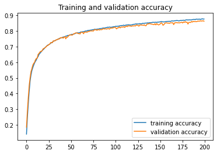

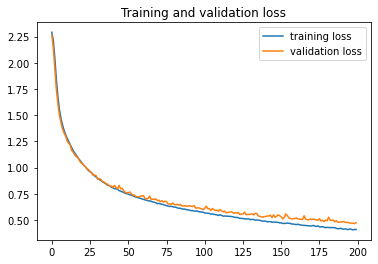

```python
accuracy      = training_history_adam2.history['accuracy']
val_accuracy  = training_history_adam2.history['val_accuracy']
loss     = training_history_adam2.history['loss']
val_loss = training_history_adam2.history['val_loss']

epochs   = range(len(accuracy)) # Get number of epochs

plt.plot  ( epochs, accuracy, label = 'training accuracy' )
plt.plot  ( epochs, val_accuracy, label = 'validation accuracy' )
plt.title ('Training and validation accuracy')
plt.legend(loc = 'lower right')
plt.figure()

plt.plot  ( epochs, loss, label = 'training loss' )
plt.plot  ( epochs, val_loss, label = 'validation loss' )
plt.legend(loc = 'upper right')
plt.title ('Training and validation loss'   )
```

**Comments:**

- Accuracy for the Training and validation also same for the finalized model, there is only very little overfitting observed. The model performs well in training and validation set
- Validation loss and Training Loss graph is almost similar for this model. For 200 Epochs the loss started from 2.25 and reahed less than 0.75
- The graph clearly says the model performs best.

```
Predicted label: 6
Softmax Outputs: [[1.0358894e-05 1.8508836e-06 3.8641468e-09 5.7615830e-07 6.7449564e-06
  2.7385427e-04 9.9642229e-01 2.8801923e-08 3.2827228e-03 1.6754494e-06]]
1.0000001
```

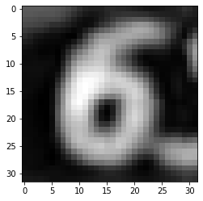

```python
import matplotlib.pyplot as plt
%matplotlib inline
plt.imshow(X_test[500].reshape(32, 32), cmap='gray')
y_pred = model_4.predict(X_test[500].reshape(1, 32, 32, 1))
print("Predicted label:", y_pred.argmax())
print("Softmax Outputs:", y_pred)
print(y_pred.sum())
```